# JOSS submission analytics

2026-08-05 09:50:40.204507

# Introduction

In this report, we extract information about published JOSS papers and generate  
graphics as well as a summary table that can be downloaded and used for further analyses.

# Load required R packages

```r
suppressPackageStartupMessages({
    library(tibble)
    library(rcrossref)
    library(dplyr)
    library(tidyr)
    library(ggplot2)
    library(lubridate)
    library(gh)
    library(purrr)
    library(jsonlite)
    library(DT)
    library(plotly)
    library(citecorp)
    library(readr)
    library(rworldmap)
    library(gt)
    library(stringr)
    library(openalexR)
    library(arrow)
    library(jsonlite)
})
```

```r
## Keep track of the source of each column
source_track <- c()

## Determine whether to add a caption with today's date to the (non-interactive) plots
add_date_caption <- TRUE
if (add_date_caption) {
    dcap <- lubridate::today()
} else {
    dcap <- ""
}
```

```r
## Get list of countries and populations (2022) from the rworldmap/gt packages
data("countrySynonyms")
country_names <- countrySynonyms |>
    select(-ID) |>
    pivot_longer(names_to = "tmp", values_to = "name", -ISO3) |>
    filter(name != "") |>
    select(-tmp)

## Country population data from the World Bank (https://data.worldbank.org/indicator/SP.POP.TOTL),
## distributed via the gt R package
country_populations <- countrypops |>
    filter(year == 2022)
```

```r
## Read archived version of summary data frame, to use for filling in
## information about software repositories (due to limit on API requests)
## Sort by the date when software repo info was last obtained
papers_archive <- readRDS(gzcon(url("https://github.com/openjournals/joss-analytics/blob/gh-pages/joss_submission_analytics.rds?raw=true"))) %>%
    dplyr::arrange(!is.na(repo_info_obtained), repo_info_obtained)

## Similarly for citation analysis, to avoid having to pull down the
## same information multiple times
citations_archive <- readr::read_delim(
    url("https://github.com/openjournals/joss-analytics/blob/gh-pages/joss_submission_citations.tsv?raw=true"),
    col_types = cols(.default = "c"), col_names = TRUE,
    delim = "\t")
```

# Collect information about papers

## Pull down paper info from Crossref and citation information from OpenAlex

We get the information about published JOSS papers from Crossref, using the `rcrossref` R package. The `openalexR` R package is used to extract citation counts from OpenAlex.

```r
## First check how many records there are in Crossref
issn <- "2475-9066"
joss_details <- rcrossref::cr_journals(issn, works = FALSE) %>%
    pluck("data")
(total_dois <- joss_details$total_dois)
```

```
## [1] 3652
```

```r
## Pull down all records from Crossref
papers <- rcrossref::cr_journals(issn, works = TRUE, cursor = "*",
    cursor_max = joss_details$total_dois * 2) %>%
    pluck("data")

## Only keep articles
papers <- papers %>%
    dplyr::filter(type == "journal-article")
dim(papers)
```

```
## [1] 3652   28
```

```r
dim(papers %>% distinct())
```

```
## [1] 3652   28
```

```r
## Check that all papers were pulled down and stop otherwise
if (!(nrow(papers %>% distinct()) >= total_dois)) {
    stop("Not all papers were pulled down from Crossref!")
}

## A few papers don't have alternative.ids - generate them from the DOI
noaltid <- which(is.na(papers$alternative.id))
papers$alternative.id[noaltid] <- papers$doi[noaltid]

## Get citation info from Crossref and merge with paper details
# cit <- rcrossref::cr_citation_count(doi = papers$alternative.id)
# papers <- papers %>% dplyr::left_join(
#     cit %>% dplyr::rename(citation_count = count),
#     by = c("alternative.id" = "doi")
# )

## Remove one duplicated paper
papers <- papers %>% dplyr::filter(alternative.id != "10.21105/joss.00688")
dim(papers)
```

```
## [1] 3651   28
```

```r
dim(papers %>% distinct())
```

```
## [1] 3651   28
```

```r
papers$alternative.id[duplicated(papers$alternative.id)]
```

```
## character(0)
```

```r
source_track <- c(source_track,
                  structure(rep("crossref", ncol(papers)),
                            names = colnames(papers)))
```

```r
## Get info from openalexR and merge with paper details
## Helper function to extract countries from affiliations. Note that this
## information is not available for all papers.
.get_countries <- function(df, wh = "first") {
    if ((length(df) == 1 && is.na(df)) || is.null(df$affiliations)) {
        ""
    } else {
        if (wh == "first") {
            ## Only first affiliation for each author
            tmp <- unnest(df, cols = c(affiliations), names_sep = "_") |>
                dplyr::filter(!duplicated(id) & !is.na(affiliations_country_code)) |>
                pull(affiliations_country_code)
        } else {
            ## All affiliations
            tmp <- unnest(df, cols = c(affiliations), names_sep = "_") |>
                dplyr::filter(!is.na(affiliations_country_code)) |>
                pull(affiliations_country_code)
        }
        if (length(tmp) > 0) {
            tmp |>
                unique() |>
                paste(collapse = ";")
        } else {
            ""
        }
    }
}

oa <- oa_fetch(entity = "works",
               primary_location.source.id = "s4210214273") |>
    mutate(affil_countries_all = vapply(authorships, .get_countries, "", wh = "all"),
           affil_countries_first = vapply(authorships, .get_countries, "", wh = "first"))
dim(oa)
```

```
## [1] 3655   45
```

```r
length(unique(oa$doi))
```

```
## [1] 3652
```

```r
papers <- papers %>% dplyr::left_join(
    oa %>% dplyr::mutate(alternative.id = sub("https://doi.org/", "", doi)) %>%
        dplyr::select(alternative.id, cited_by_count, id,
                      affil_countries_all, affil_countries_first) %>%
        dplyr::rename(citation_count = cited_by_count,
                      openalex_id = id),
    by = "alternative.id"
)
dim(papers)
```

```
## [1] 3654   32
```

```r
dim(papers %>% distinct())
```

```
## [1] 3654   32
```

```r
source_track <- c(source_track,
                  structure(rep("OpenAlex", length(setdiff(colnames(papers),
                                                           names(source_track)))),
                            names = setdiff(colnames(papers), names(source_track))))
```

## Pull down info from JOSS API

For each published paper, we use the JOSS API to get information about pre-review and review issue numbers, corresponding software repository etc.

```r
joss_api <- list()
p <- 1
a0 <- NULL
a <- jsonlite::fromJSON(
    url(paste0("https://joss.theoj.org/papers/published.json?page=", p)),
    simplifyDataFrame = FALSE
)
while (length(a) > 0 && !identical(a, a0)) {
    joss_api <- c(joss_api, a)
    p <- p + 1
    a0 <- a
    a <- tryCatch({
        jsonlite::fromJSON(
            url(paste0("https://joss.theoj.org/papers/published.json?page=", p)),
            simplifyDataFrame = FALSE
        )},
        error = function(e) return(numeric(0))
    )
}

joss_api <- do.call(dplyr::bind_rows, lapply(joss_api, function(w) {
    data.frame(api_title = w$title,
               api_state = w$state,
               author_affiliations = paste(unique(unlist(lapply(w$authors, "[[", "affiliation"))), collapse = ";"),
               editor = paste(w$editor, collapse = ","),
               reviewers = paste(w$reviewers, collapse = ","),
               nbr_reviewers = length(w$reviewers),
               repo_url = w$software_repository,
               review_issue_id = sub("https://github.com/openjournals/joss-reviews/issues/",
                                     "", w$paper_review),
               doi = w$doi,
               prereview_issue_id = ifelse(!is.null(w$meta_review_issue_id),
                                           w$meta_review_issue_id, NA_integer_),
               languages = gsub(", ", ",", w$languages),
               archive_doi = w$software_archive)
}))
dim(joss_api)
```

```
## [1] 3652   12
```

```r
dim(joss_api %>% distinct())
```

```
## [1] 3652   12
```

```r
## Check that all papers were pulled down and stop otherwise
if (!(nrow(joss_api %>% distinct()) >= total_dois)) {
    stop("Not all papers were pulled down from the JOSS API!")
}
joss_api$repo_url[duplicated(joss_api$repo_url)]
```

```
##  [1] "https://gitlab.com/mauricemolli/petitRADTRANS"
##  [2] "https://github.com/nomad-coe/greenX"
##  [3] "https://github.com/mdhaber/scipy"
##  [4] "https://github.com/idaholab/moose"
##  [5] "https://gitlab.com/libreumg/dataquier.git"
##  [6] "https://github.com/idaholab/moose"
##  [7] "https://github.com/dynamicslab/pysindy"
##  [8] "https://github.com/landlab/landlab"
##  [9] "https://github.com/landlab/landlab"
## [10] "https://github.com/symmy596/SurfinPy"
## [11] "https://github.com/arviz-devs/arviz"
## [12] "https://github.com/bcgov/ssdtools"
## [13] "https://github.com/landlab/landlab"
## [14] "https://github.com/pvlib/pvlib-python"
## [15] "https://github.com/mlpack/mlpack"
## [16] "https://github.com/julia-wrobel/registr"
## [17] "https://github.com/barbagroup/pygbe"
```

```r
papers <- papers %>% dplyr::left_join(joss_api, by = c("alternative.id" = "doi"))
dim(papers)
```

```
## [1] 3654   43
```

```r
dim(papers %>% distinct())
```

```
## [1] 3654   43
```

```r
papers$repo_url[duplicated(papers$repo_url)]
```

```
##  [1] "https://github.com/mlpack/mlpack"
##  [2] "https://github.com/QTC-UMD/rydiqule"
##  [3] "https://github.com/nomad-coe/greenX"
##  [4] "https://github.com/bcgov/ssdtools"
##  [5] "https://github.com/barbagroup/pygbe"
##  [6] "https://github.com/dynamicslab/pysindy"
##  [7] "https://github.com/landlab/landlab"
##  [8] "https://github.com/idaholab/moose"
##  [9] "https://github.com/idaholab/moose"
## [10] "https://github.com/adityapt/deepcausalmmm/"
## [11] "https://gitlab.com/mauricemolli/petitRADTRANS"
## [12] "https://github.com/landlab/landlab"
## [13] "https://github.com/arviz-devs/arviz"
## [14] "https://github.com/symmy596/SurfinPy"
## [15] "https://github.com/fluhus/blini"
## [16] "https://github.com/mdhaber/scipy"
## [17] "https://github.com/julia-wrobel/registr"
## [18] "https://github.com/pvlib/pvlib-python"
## [19] "https://gitlab.com/libreumg/dataquier.git"
## [20] "https://github.com/landlab/landlab"
```

```r
source_track <- c(source_track,
                  structure(rep("JOSS_API", length(setdiff(colnames(papers),
                                                           names(source_track)))),
                            names = setdiff(colnames(papers), names(source_track))))
```

## Combine with info from GitHub issues

From each pre-review and review issue, we extract information about review times and assigned labels.

```r
## Pull down info on all issues in the joss-reviews repository
issues <- gh("/repos/openjournals/joss-reviews/issues",
             .limit = 15000, state = "all")
```

```r
## From each issue, extract required information
iss <- do.call(dplyr::bind_rows, lapply(issues, function(i) {
    data.frame(title = i$title,
               number = i$number,
               state = i$state,
               opened = i$created_at,
               closed = ifelse(!is.null(i$closed_at),
                               i$closed_at, NA_character_),
               ncomments = i$comments,
               labels = paste(setdiff(
                   vapply(i$labels, getElement,
                          name = "name", character(1L)),
                   c("review", "pre-review", "query-scope", "paused")),
                   collapse = ","))
}))

## Split into REVIEW, PRE-REVIEW, and other issues (the latter category
## is discarded)
issother <- iss %>% dplyr::filter(!grepl("\\[PRE REVIEW\\]", title) &
                                      !grepl("\\[REVIEW\\]", title))
dim(issother)
```

```
## [1] 205   7
```

```r
head(issother)
```

```
##                                                                                                   title
## 1                                                                                                   ...
## 2 [joss][question] Clarify review target: paper branch (joss) diverges from and lags the v0.7.0 release
## 3                                              Question About JOSS Reviewer Selection and Participation
## 4                                         Minor language, grammar, and readability issues in manuscript
## 5                                                Clarify wording on collaborative effort checklist item
## 6                                                                       Please withdraw this submission
##   number  state               opened               closed ncomments labels
## 1  10901 closed 2026-07-07T09:47:42Z 2026-07-07T09:47:45Z         1
## 2  10776 closed 2026-06-21T15:23:11Z 2026-06-21T15:23:13Z         1
## 3  10655 closed 2026-06-06T20:41:42Z 2026-06-06T20:41:44Z         1
## 4  10593 closed 2026-05-19T15:52:52Z 2026-05-19T15:52:55Z         1
## 5  10450 closed 2026-04-21T09:37:27Z 2026-04-21T12:21:04Z         0
## 6  10226 closed 2026-03-18T00:48:15Z 2026-03-18T00:48:17Z         1
```

```r
## For REVIEW issues, generate the DOI of the paper from the issue number
getnbrzeros <- function(s) {
    paste(rep(0, 5 - nchar(s)), collapse = "")
}
issrev <- iss %>% dplyr::filter(grepl("\\[REVIEW\\]", title)) %>%
    dplyr::mutate(nbrzeros = purrr::map_chr(number, getnbrzeros)) %>%
    dplyr::mutate(alternative.id = paste0("10.21105/joss.",
                                          nbrzeros,
                                          number)) %>%
    dplyr::select(-nbrzeros) %>%
    dplyr::mutate(title = gsub("\\[REVIEW\\]: ", "", title)) %>%
    dplyr::rename_at(vars(-alternative.id), ~ paste0("review_", .))
```

```r
## For pre-review and review issues, respectively, get the number of
## issues closed each month, and the number of those that have the
## 'rejected' label
review_rejected <- iss %>%
    dplyr::filter(grepl("\\[REVIEW\\]", title)) %>%
    dplyr::filter(!is.na(closed)) %>%
    dplyr::mutate(closedmonth = lubridate::floor_date(as.Date(closed), "month")) %>%
    dplyr::group_by(closedmonth) %>%
    dplyr::summarize(nbr_issues_closed = length(labels),
                     nbr_rejections = sum(grepl("rejected", labels))) %>%
    dplyr::mutate(itype = "review")

prereview_rejected <- iss %>%
    dplyr::filter(grepl("\\[PRE REVIEW\\]", title)) %>%
    dplyr::filter(!is.na(closed)) %>%
    dplyr::mutate(closedmonth = lubridate::floor_date(as.Date(closed), "month")) %>%
    dplyr::group_by(closedmonth) %>%
    dplyr::summarize(nbr_issues_closed = length(labels),
                     nbr_rejections = sum(grepl("rejected", labels))) %>%
    dplyr::mutate(itype = "pre-review")

all_rejected <- dplyr::bind_rows(review_rejected, prereview_rejected)
```

```r
## Get only pre-review issues plus review issues opened before 2016-09-18,
## will use these as a proxy for the number of submissions
pi1 <- iss |>
    dplyr::filter(grepl("\\[PRE REVIEW\\]", title)) |>
    dplyr::mutate(opened = as.Date(opened))
dim(pi1)
```

```
## [1] 6735    7
```

```r
pi2 <- iss |>
    dplyr::filter(grepl("\\[REVIEW\\]", title)) |>
    dplyr::mutate(opened = as.Date(opened)) |>
    dplyr::filter(opened <= as.Date("2016-09-18"))
dim(pi2)
```

```
## [1] 49  7
```

```r
prereview_issues <- dplyr::bind_rows(pi1, pi2)
```

```r
## For PRE-REVIEW issues, add information about the corresponding REVIEW
## issue number
isspre <- iss %>% dplyr::filter(grepl("\\[PRE REVIEW\\]", title)) %>%
    dplyr::filter(!grepl("withdrawn", labels)) %>%
    dplyr::filter(!grepl("rejected", labels))
## Some titles have multiple pre-review issues. In these cases, keep the latest
isspre <- isspre %>% dplyr::arrange(desc(number)) %>%
    dplyr::filter(!duplicated(title)) %>%
    dplyr::mutate(title = gsub("\\[PRE REVIEW\\]: ", "", title)) %>%
    dplyr::rename_all(~ paste0("prerev_", .))

papers <- papers %>% dplyr::left_join(issrev, by = "alternative.id") %>%
    dplyr::left_join(isspre, by = c("prereview_issue_id" = "prerev_number")) %>%
    dplyr::mutate(prerev_opened = as.Date(prerev_opened),
                  prerev_closed = as.Date(prerev_closed),
                  review_opened = as.Date(review_opened),
                  review_closed = as.Date(review_closed)) %>%
    dplyr::mutate(days_in_pre = prerev_closed - prerev_opened,
                  days_in_rev = review_closed - review_opened,
                  to_review = !is.na(review_opened))
dim(papers)
```

```
## [1] 3654   59
```

```r
dim(papers %>% distinct())
```

```
## [1] 3654   59
```

```r
source_track <- c(source_track,
                  structure(rep("joss-github", length(setdiff(colnames(papers),
                                                              names(source_track)))),
                            names = setdiff(colnames(papers), names(source_track))))
```

## Add information from software repositories

```r
## Reorder so that software repositories that were interrogated longest
## ago are checked first
tmporder <- order(match(papers$alternative.id, papers_archive$alternative.id),
                  na.last = FALSE)
software_urls <- papers$repo_url[tmporder]
software_urls[duplicated(software_urls)]
```

```
##  [1] "https://gitlab.com/mauricemolli/petitRADTRANS"
##  [2] "https://gitlab.com/libreumg/dataquier.git"
##  [3] "https://github.com/bcgov/ssdtools"
##  [4] "https://github.com/dynamicslab/pysindy"
##  [5] "https://github.com/arviz-devs/arviz"
##  [6] "https://github.com/symmy596/SurfinPy"
##  [7] "https://github.com/fluhus/blini"
##  [8] "https://github.com/mdhaber/scipy"
##  [9] "https://github.com/mlpack/mlpack"
## [10] "https://github.com/QTC-UMD/rydiqule"
## [11] "https://github.com/nomad-coe/greenX"
## [12] "https://github.com/barbagroup/pygbe"
## [13] "https://github.com/landlab/landlab"
## [14] "https://github.com/idaholab/moose"
## [15] "https://github.com/idaholab/moose"
## [16] "https://github.com/adityapt/deepcausalmmm/"
## [17] "https://github.com/landlab/landlab"
## [18] "https://github.com/julia-wrobel/registr"
## [19] "https://github.com/pvlib/pvlib-python"
## [20] "https://github.com/landlab/landlab"
```

```r
is_github <- grepl("github", software_urls)
length(is_github)
```

```
## [1] 3654
```

```r
sum(is_github)
```

```
## [1] 3468
```

```r
software_urls[!is_github]
```

```
##   [1] "https://gitlab.com/ENKI-portal/ThermoCodegen"
##   [2] "https://gitlab.com/oali/dxtr"
##   [3] "https://bitbucket.org/orionmhdteam/orion2_release1/src/master/"
##   [4] "https://gitlab.com/morikawa-lab-osakau/vibir-parallel-compute"
##   [5] "https://gitlab.kuleuven.be/ITSCreaLab/public-toolboxes/dyntapy"
##   [6] "https://gitlab.dune-project.org/copasi/dune-copasi"
##   [7] "https://gitlab.com/bonsamurais/bonsai/util/ipcc"
##   [8] "https://gite.lirmm.fr/doccy/RedOak"
##   [9] "https://codebase.helmholtz.cloud/mussel/netlogo-northsea-species.git"
##  [10] "https://gitlab.com/ffaucher/hawen"
##  [11] "https://gitlab.com/cmbm-ethz/miop"
##  [12] "https://gitlab.com/cosmograil/starred"
##  [13] "https://gitlab.com/emd-dev/emd"
##  [14] "https://bitbucket.org/rram/dvrlib/src/joss/"
##  [15] "https://gitlab.com/mantik-ai/mantik"
```

[output cut: 171 more lines]

```r
df <- do.call(dplyr::bind_rows, lapply(unique(software_urls[is_github]), function(u) {
    u0 <- gsub("^http://", "https://", gsub("\\.git$", "", gsub("/$", "", u)))
    if (grepl("/tree/", u0)) {
        u0 <- strsplit(u0, "/tree/")[[1]][1]
    }
    if (grepl("/blob/", u0)) {
        u0 <- strsplit(u0, "/blob/")[[1]][1]
    }
    info <- try({
        gh(gsub("(https://)?(www.)?github.com/", "/repos/", u0))
    })
    languages <- try({
        gh(paste0(gsub("(https://)?(www.)?github.com/", "/repos/", u0), "/languages"),
           .limit = 500)
    })
    topics <- try({
        gh(paste0(gsub("(https://)?(www.)?github.com/", "/repos/", u0), "/topics"),
           .accept = "application/vnd.github.mercy-preview+json", .limit = 500)
    })
    contribs <- try({
        gh(paste0(gsub("(https://)?(www.)?github.com/", "/repos/", u0), "/contributors"),
           .limit = 500)
    })
    if (!is(info, "try-error") && length(info) > 1) {
        if (!is(contribs, "try-error")) {
            if (length(contribs) == 0) {
                repo_nbr_contribs <- repo_nbr_contribs_2ormore <- NA_integer_
            } else {
                repo_nbr_contribs <- length(contribs)
                repo_nbr_contribs_2ormore <- sum(vapply(contribs, function(x) x$contributions >= 2, NA_integer_))
                if (is.na(repo_nbr_contribs_2ormore)) {
                    print(contribs)
                }
            }
        } else {
            repo_nbr_contribs <- repo_nbr_contribs_2ormore <- NA_integer_
        }

        if (!is(languages, "try-error")) {
            if (length(languages) == 0) {
                repolang <- ""
            } else {
                repolang <- paste(paste(names(unlist(languages)),
                                        unlist(languages), sep = ":"), collapse = ",")
            }
        } else {
            repolang <- ""
        }

        if (!is(topics, "try-error")) {
            if (length(topics$names) == 0) {
                repotopics <- ""
            } else {
                repotopics <- paste(unlist(topics$names), collapse = ",")
            }
        } else {
            repotopics <- ""
        }

        data.frame(repo_url = u,
                   repo_created = info$created_at,
                   repo_updated = info$updated_at,
                   repo_pushed = info$pushed_at,
                   repo_nbr_stars = info$stargazers_count,
                   repo_language = ifelse(!is.null(info$language),
                                          info$language, NA_character_),
                   repo_languages_bytes = repolang,
                   repo_topics = repotopics,
                   repo_license = ifelse(!is.null(info$license),
                                         info$license$key, NA_character_),
                   repo_nbr_contribs = repo_nbr_contribs,
                   repo_nbr_contribs_2ormore = repo_nbr_contribs_2ormore
        )
    } else {
        NULL
    }
})) %>%
    dplyr::mutate(repo_created = as.Date(repo_created),
                  repo_updated = as.Date(repo_updated),
                  repo_pushed = as.Date(repo_pushed)) %>%
    dplyr::distinct() %>%
    dplyr::mutate(repo_info_obtained = lubridate::today())
```

```r
if (length(unique(df$repo_url)) != length(df$repo_url)) {
    print(length(unique(df$repo_url)))
    print(length(df$repo_url))
    print(df$repo_url[duplicated(df$repo_url)])
}
stopifnot(length(unique(df$repo_url)) == length(df$repo_url))
dim(df)
```

```
## [1] 2257   12
```

```r
## For papers not in df (i.e., for which we didn't get a valid response
## from the GitHub API query), use information from the archived data frame
dfarchive <- papers_archive %>%
    dplyr::select(colnames(df)[colnames(df) %in% colnames(papers_archive)]) %>%
    dplyr::filter(!(repo_url %in% df$repo_url)) %>%
    dplyr::arrange(desc(repo_info_obtained)) %>%
    dplyr::filter(!duplicated(repo_url))
head(dfarchive)
```

```
## # A tibble: 6 × 12
##   repo_url    repo_created repo_updated repo_pushed repo_nbr_stars repo_language
##   <chr>       <date>       <date>       <date>               <int> <chr>
## 1 https://gi… 2021-07-24   2025-03-15   2025-03-15               0 Java
## 2 https://gi… 2018-02-06   2024-11-03   2021-06-28              46 Python
## 3 https://gi… 2018-05-27   2026-03-25   2026-03-25             120 R
## 4 https://gi… 2015-03-04   2025-03-22   2022-05-10              55 R
## 5 https://gi… 2017-12-08   2020-03-24   2018-09-30               1 Java
## 6 https://gi… 2016-05-09   2026-01-06   2021-07-26              35 MATLAB
## # ℹ 6 more variables: repo_languages_bytes <chr>, repo_topics <chr>,
## #   repo_license <chr>, repo_nbr_contribs <int>,
## #   repo_nbr_contribs_2ormore <int>, repo_info_obtained <date>
```

```r
dim(dfarchive)
```

```
## [1] 1377   12
```

```r
df <- dplyr::bind_rows(df, dfarchive)
stopifnot(length(unique(df$repo_url)) == length(df$repo_url))
dim(df)
```

```
## [1] 3634   12
```

```r
papers <- papers %>% dplyr::left_join(df, by = "repo_url")
dim(papers)
```

```
## [1] 3654   70
```

```r
source_track <- c(source_track,
                  structure(rep("sw-github", length(setdiff(colnames(papers),
                                                            names(source_track)))),
                            names = setdiff(colnames(papers), names(source_track))))
```

## Clean up a bit

```r
## Convert publication date to Date format
## Add information about the half year (H1, H2) of publication
## Count number of authors
papers <- papers %>% dplyr::select(-reference, -license, -link) %>%
    dplyr::mutate(published.date = as.Date(published.print)) %>%
    dplyr::mutate(
        halfyear = paste0(year(published.date),
                          ifelse(month(published.date) <= 6, "H1", "H2"))
    ) %>% dplyr::mutate(
        halfyear = factor(halfyear,
                          levels = paste0(rep(sort(unique(year(published.date))),
                                              each = 2), c("H1", "H2")))
    ) %>% dplyr::mutate(nbr_authors = vapply(author, function(a) nrow(a), NA_integer_))
dim(papers)
```

```
## [1] 3654   70
```

```r
dupidx <- which(papers$alternative.id %in% papers$alternative.id[duplicated(papers)])
papers[dupidx, ] %>% arrange(alternative.id) %>% head(n = 10)
```

```
## # A tibble: 0 × 70
## # ℹ 70 variables: alternative.id <chr>, container.title <chr>, created <chr>,
## #   deposited <chr>, published.print <chr>, doi <chr>, indexed <chr>,
## #   issn <chr>, issue <chr>, issued <chr>, member <chr>, page <chr>,
## #   prefix <chr>, publisher <chr>, score <chr>, source <chr>,
## #   reference.count <chr>, references.count <chr>,
## #   is.referenced.by.count <chr>, title <chr>, type <chr>, url <chr>,
## #   volume <chr>, short.container.title <chr>, author <list>, …
```

```r
papers <- papers %>% dplyr::distinct()
dim(papers)
```

```
## [1] 3654   70
```

```r
source_track <- c(source_track,
                  structure(rep("cleanup", length(setdiff(colnames(papers),
                                                          names(source_track)))),
                            names = setdiff(colnames(papers), names(source_track))))
```

# Tabulate number of missing values

In some cases, fetching information from (e.g.) the GitHub API fails for a subset of the publications. There are also other reasons for missing values (for example, the earliest submissions do not have an associated pre-review issue). The table below lists the number of missing values for each of the variables in the data frame.

```r
DT::datatable(
    data.frame(variable = colnames(papers),
               nbr_missing = colSums(is.na(papers))) %>%
        dplyr::mutate(source = source_track[variable]),
    escape = FALSE, rownames = FALSE,
    filter = list(position = 'top', clear = FALSE),
    options = list(scrollX = TRUE)
)
```

| variable | nbr_missing | source |
| --- | --- | --- |
| alternative.id | 0 | crossref |
| container.title | 0 | crossref |
| created | 0 | crossref |
| deposited | 0 | crossref |
| published.print | 0 | crossref |
| doi | 0 | crossref |
| indexed | 0 | crossref |
| issn | 0 | crossref |
| issue | 0 | crossref |
| issued | 0 | crossref |

[output cut: 60 more lines]

# Number of published papers per month

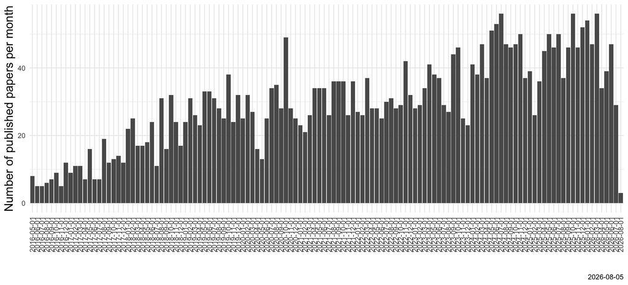

```r
monthly_pubs <- papers %>%
    dplyr::mutate(pubmonth = lubridate::floor_date(published.date, "month")) %>%
    dplyr::group_by(pubmonth) %>%
    dplyr::summarize(npub = n())
ggplot(monthly_pubs,
       aes(x = factor(pubmonth), y = npub)) +
    geom_bar(stat = "identity") + theme_minimal() +
    labs(x = "", y = "Number of published papers per month", caption = dcap) +
    theme(axis.title = element_text(size = 15),
          axis.text.x = element_text(angle = 90, hjust = 1, vjust = 0.5))
```

```r
DT::datatable(
    monthly_pubs %>%
        dplyr::rename("Number of papers" = "npub",
                      "Month of publication" = "pubmonth"),
    escape = FALSE, rownames = FALSE,
    filter = list(position = 'top', clear = FALSE),
    options = list(scrollX = TRUE)
)
```

| Month of publication | Number of papers |
| --- | --- |
| 2016-05-01 | 8 |
| 2016-06-01 | 5 |
| 2016-07-01 | 5 |
| 2016-08-01 | 6 |
| 2016-09-01 | 7 |
| 2016-10-01 | 9 |
| 2016-11-01 | 5 |
| 2016-12-01 | 12 |
| 2017-01-01 | 9 |
| 2017-02-01 | 11 |

[output cut: 114 more lines]

# Number of published papers per year

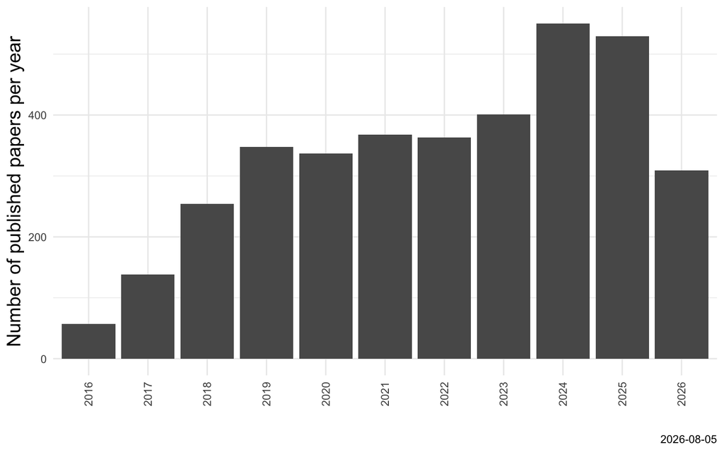

```r
yearly_pubs <- papers %>%
    dplyr::mutate(pubyear = lubridate::year(published.date)) %>%
    dplyr::group_by(pubyear) %>%
    dplyr::summarize(npub = n())
ggplot(yearly_pubs,
       aes(x = factor(pubyear), y = npub)) +
    geom_bar(stat = "identity") + theme_minimal() +
    labs(x = "", y = "Number of published papers per year", caption = dcap) +
    theme(axis.title = element_text(size = 15),
          axis.text.x = element_text(angle = 90, hjust = 1, vjust = 0.5))
```

```r
DT::datatable(
    yearly_pubs %>%
        dplyr::rename("Number of papers" = "npub",
                      "Year of publication" = "pubyear"),
    escape = FALSE, rownames = FALSE,
    filter = list(position = 'top', clear = FALSE),
    options = list(scrollX = TRUE)
)
```

| Year of publication | Number of papers |
| --- | --- |
| 2016 | 57 |
| 2017 | 138 |
| 2018 | 254 |
| 2019 | 348 |
| 2020 | 337 |
| 2021 | 368 |
| 2022 | 363 |
| 2023 | 401 |
| 2024 | 550 |
| 2025 | 529 |

[output cut: 1 more lines]

# Number of submissions per month

We use the number of opened pre-review issues in a month as a proxy for the number of submissions.

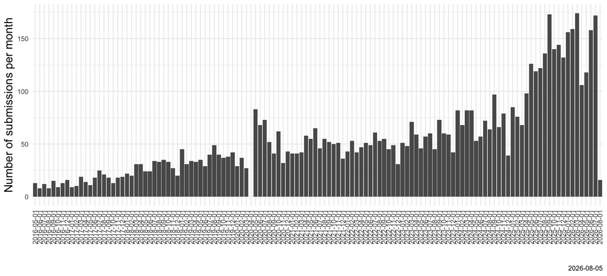

```r
monthly_subs <- prereview_issues |>
    dplyr::mutate(submonth = lubridate::floor_date(opened, "month")) |>
    dplyr::group_by(submonth) |>
    dplyr::summarize(nsub = n()) |>
    # fill in missing months (with 0 submissions)
    tidyr::complete(
        submonth = seq(min(submonth, na.rm = TRUE),
                       max(submonth, na.rm = TRUE), by = "month"),
        fill = list(nsub = 0)
     )
ggplot(monthly_subs,
       aes(x = factor(submonth), y = nsub)) +
    geom_bar(stat = "identity") + theme_minimal() +
    labs(x = "", y = "Number of submissions per month", caption = dcap) +
    theme(axis.title = element_text(size = 15),
          axis.text.x = element_text(angle = 90, hjust = 1, vjust = 0.5))
```

```r
DT::datatable(
    monthly_subs |>
        dplyr::rename("Number of submissions" = "nsub",
                      "Month of submission" = "submonth"),
    escape = FALSE, rownames = FALSE,
    filter = list(position = 'top', clear = FALSE),
    options = list(scrollX = TRUE)
)
```

| Month of submission | Number of submissions |
| --- | --- |
| 2016-05-01 | 13 |
| 2016-06-01 | 8 |
| 2016-07-01 | 12 |
| 2016-08-01 | 8 |
| 2016-09-01 | 15 |
| 2016-10-01 | 9 |
| 2016-11-01 | 13 |
| 2016-12-01 | 16 |
| 2017-01-01 | 9 |
| 2017-02-01 | 10 |

[output cut: 114 more lines]

# Fraction rejected papers

The plots below illustrate the fraction of pre-review and review issues closed during each month that have the ‘rejected’ label attached.

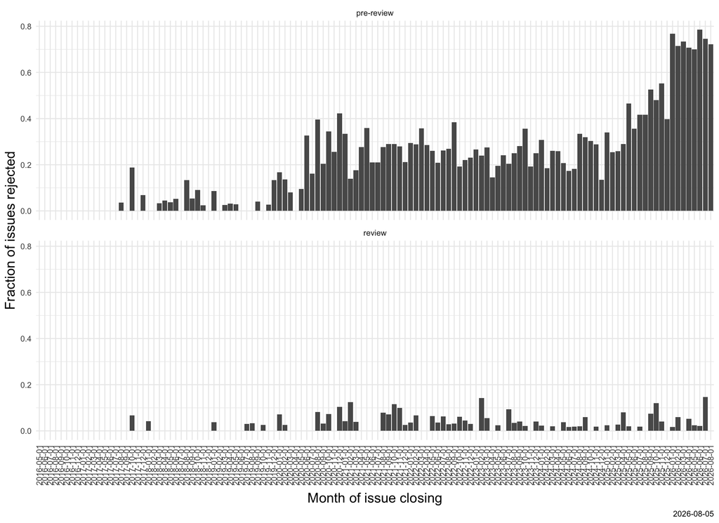

```r
ggplot(all_rejected,
       aes(x = factor(closedmonth), y = nbr_rejections/nbr_issues_closed)) +
    geom_bar(stat = "identity") +
    theme_minimal() +
    facet_wrap(~ itype, ncol = 1) +
    labs(x = "Month of issue closing", y = "Fraction of issues rejected",
         caption = dcap) +
    theme(axis.title = element_text(size = 15),
          axis.text.x = element_text(angle = 90, hjust = 1, vjust = 0.5))
```

# Citation distribution

Papers with 20 or more citations are grouped in the “>=20” category.

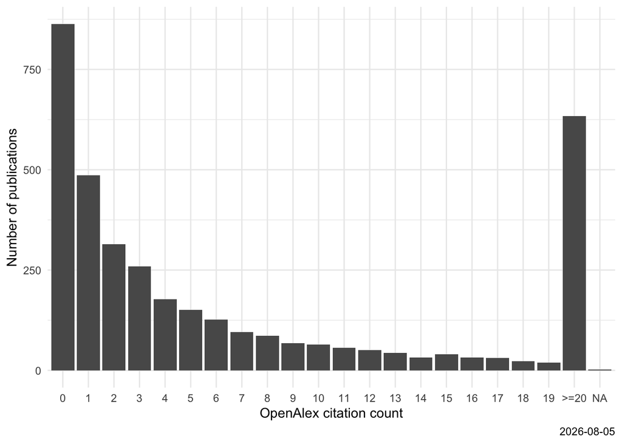

```r
ggplot(papers %>%
           dplyr::mutate(citation_count = replace(citation_count,
                                                  citation_count >= 20, ">=20")) %>%
           dplyr::mutate(citation_count = factor(citation_count,
                                                 levels = c(0:20, ">=20"))) %>%
           dplyr::group_by(citation_count) %>%
           dplyr::tally(),
       aes(x = citation_count, y = n)) +
    geom_bar(stat = "identity") +
    theme_minimal() +
    labs(x = "OpenAlex citation count", y = "Number of publications", caption = dcap)
```

# Most cited papers

The table below sorts the JOSS papers in decreasing order by the number of citations in OpenAlex.

```r
DT::datatable(
    papers %>%
        dplyr::mutate(url = paste0("<a href='", url, "' target='_blank'>",
                                   url,"</a>")) %>%
        dplyr::arrange(desc(citation_count)) %>%
        dplyr::select(title, url, published.date, citation_count),
    escape = FALSE,
    filter = list(position = 'top', clear = FALSE),
    options = list(scrollX = TRUE)
)
```

|  | title | url | published.date | citation_count |
| --- | --- | --- | --- | --- |
| 1 | Welcome to the Tidyverse | https://doi.org/10.21105/joss.01686 | 2019-11-21 | 22191 |
| 2 | UMAP: Uniform Manifold Approximation and Projection | https://doi.org/10.21105/joss.00861 | 2018-09-02 | 9796 |
| 3 | performance: An R Package for Assessment, Comparison and Testing of Statistical Models | https://doi.org/10.21105/joss.03139 | 2021-04-21 | 5502 |
| 4 | hdbscan: Hierarchical density based clustering | https://doi.org/10.21105/joss.00205 | 2017-03-21 | 2753 |
| 5 | ggeffects: Tidy Data Frames of Marginal Effects from Regression Models | https://doi.org/10.21105/joss.00772 | 2018-06-29 | 2727 |
| 6 | corner.py: Scatterplot matrices in Python | https://doi.org/10.21105/joss.00024 | 2016-06-08 | 2228 |
| 7 | effectsize: Estimation of Effect Size Indices and Standardized Parameters | https://doi.org/10.21105/joss.02815 | 2020-12-23 | 2066 |
| 8 | Pingouin: statistics in Python | https://doi.org/10.21105/joss.01026 | 2018-11-19 | 1874 |
| 9 | bayestestR: Describing Effects and their Uncertainty, Existence and Significance within the Bayesian Framework | https://doi.org/10.21105/joss.01541 | 2019-08-13 | 1546 |
| 10 | SALib: An open-source Python library for Sensitivity Analysis | https://doi.org/10.21105/joss.00097 | 2017-01-10 | 1514 |

[output cut: 3644 more lines]

# Citation count vs time since publication

```r
plotly::ggplotly(
    ggplot(papers, aes(x = published.date, y = citation_count, label = title)) +
        geom_point(alpha = 0.5) + theme_bw() + scale_y_sqrt() +
        geom_smooth() +
        labs(x = "Date of publication", y = "OpenAlex citation count", caption = dcap) +
        theme(axis.title = element_text(size = 15)),
    tooltip = c("label", "x", "y")
)
```

[interactive chart not shown]

# Power law of citation count within each half year

Here, we plot the citation count for all papers published within each half year, sorted in decreasing order.

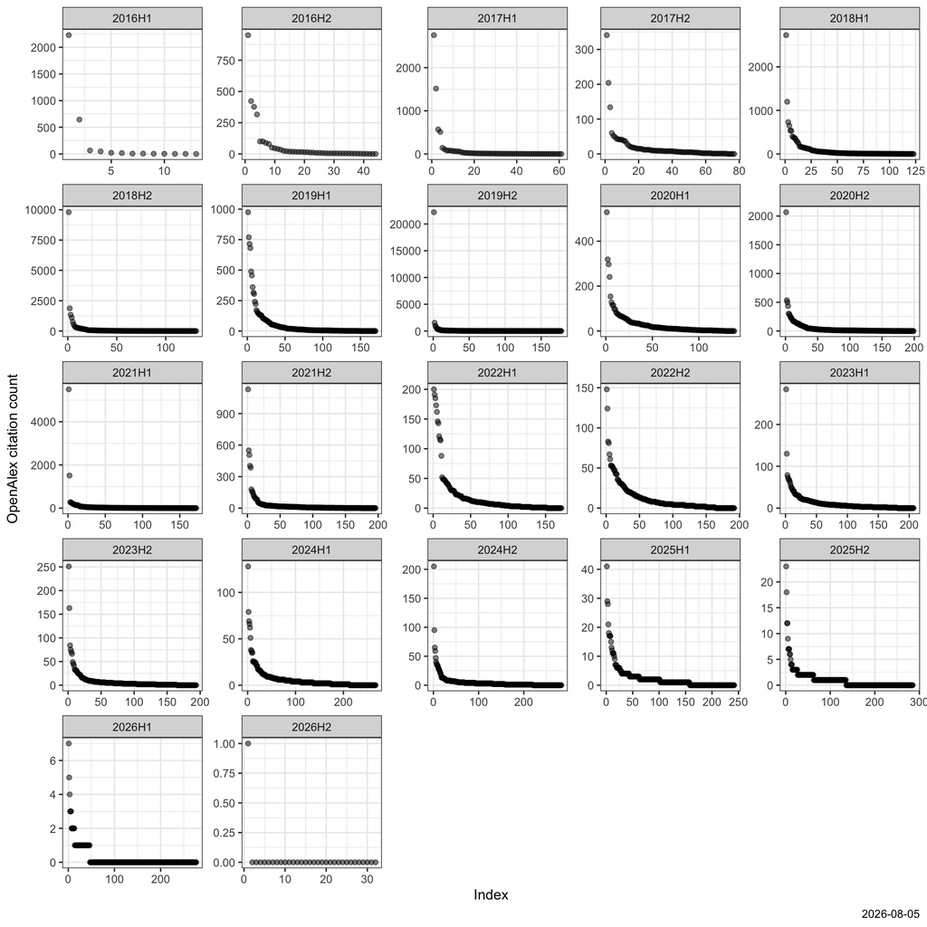

```r
ggplot(papers %>% dplyr::group_by(halfyear) %>%
           dplyr::arrange(desc(citation_count)) %>%
           dplyr::mutate(idx = seq_along(citation_count)),
       aes(x = idx, y = citation_count)) +
    geom_point(alpha = 0.5) +
    facet_wrap(~ halfyear, scales = "free") +
    theme_bw() +
    labs(x = "Index", y = "OpenAlex citation count", caption = dcap)
```

# Pre-review/review time over time

In these plots we investigate whether the time a submission spends in the pre-review or review stage (or their sum) has changed over time. The blue curve corresponds to a rolling median for submissions over 120 days.

```r
## Helper functions (modified from https://stackoverflow.com/questions/65147186/geom-smooth-with-median-instead-of-mean)
rolling_median <- function(formula, data, xwindow = 120, ...) {
    ## Get order of x-values and sort x/y
    ordr <- order(data$x)
    x <- data$x[ordr]
    y <- data$y[ordr]

    ## Initialize vector for smoothed y-values
    ys <- rep(NA, length(x))
    ## Calculate median y-value for each unique x-value
    for (xs in setdiff(unique(x), NA)) {
        ## Get x-values in the window, and calculate median of corresponding y
        j <- ((xs - xwindow/2) < x) & (x < (xs + xwindow/2))
        ys[x == xs] <- median(y[j], na.rm = TRUE)
    }
    y <- ys
    structure(list(x = x, y = y, f = approxfun(x, y)), class = "rollmed")
}

predict.rollmed <- function(mod, newdata, ...) {
    setNames(mod$f(newdata$x), newdata$x)
}
```

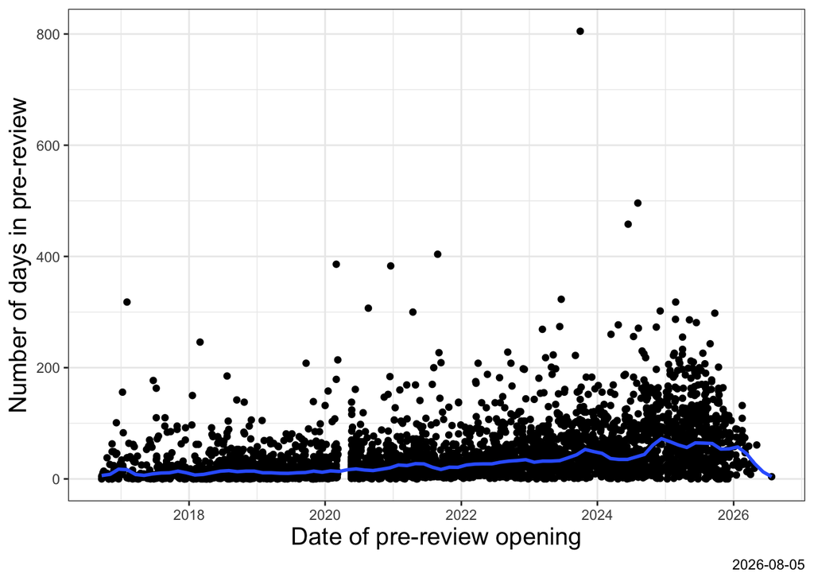

```r
ggplot(papers, aes(x = prerev_opened, y = as.numeric(days_in_pre))) +
    geom_point() +
    geom_smooth(formula = y ~ x, method = "rolling_median",
                se = FALSE, method.args = list(xwindow = 120)) +
    theme_bw() +
    labs(x = "Date of pre-review opening", y = "Number of days in pre-review",
         caption = dcap) +
    theme(axis.title = element_text(size = 15))
```

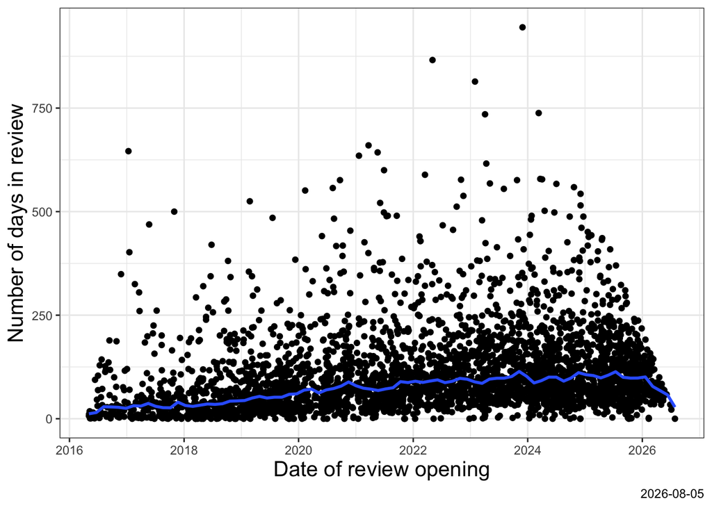

```r
ggplot(papers, aes(x = review_opened, y = as.numeric(days_in_rev))) +
    geom_point() +
    geom_smooth(formula = y ~ x, method = "rolling_median",
                se = FALSE, method.args = list(xwindow = 120)) +
    theme_bw() +
    labs(x = "Date of review opening", y = "Number of days in review",
         caption = dcap) +
    theme(axis.title = element_text(size = 15))
```

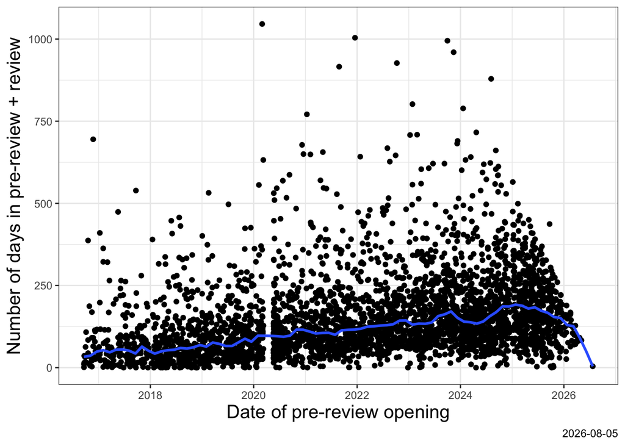

```r
ggplot(papers, aes(x = prerev_opened,
                   y = as.numeric(days_in_pre) + as.numeric(days_in_rev))) +
    geom_point() +
    geom_smooth(formula = y ~ x, method = "rolling_median",
                se = FALSE, method.args = list(xwindow = 120)) +
    theme_bw() +
    labs(x = "Date of pre-review opening", y = "Number of days in pre-review + review",
         caption = dcap) +
    theme(axis.title = element_text(size = 15))
```

# Languages

Next, we consider the languages used by the submissions, both as reported by JOSS and based on the information encoded in available GitHub repositories (for the latter, we also record the number of bytes of code written in each language). Note that a given submission can use multiple languages.

```r
## Language information from JOSS
sspl <- strsplit(papers$languages, ",")
all_languages <- unique(unlist(sspl))
langs <- do.call(dplyr::bind_rows, lapply(all_languages, function(l) {
    data.frame(language = l,
               nbr_submissions_JOSS_API = sum(vapply(sspl, function(v) l %in% v, 0)))
}))

## Language information from GitHub software repos
a <- lapply(strsplit(papers$repo_languages_bytes, ","), function(w) strsplit(w, ":"))
a <- a[sapply(a, length) > 0]
langbytes <- as.data.frame(t(as.data.frame(a))) %>%
    setNames(c("language", "bytes")) %>%
    dplyr::mutate(bytes = as.numeric(bytes)) %>%
    dplyr::filter(!is.na(language)) %>%
    dplyr::group_by(language) %>%
    dplyr::summarize(nbr_bytes_GitHub = sum(bytes),
                     nbr_repos_GitHub = length(bytes)) %>%
    dplyr::arrange(desc(nbr_bytes_GitHub))

langs <- dplyr::full_join(langs, langbytes, by = "language")
```

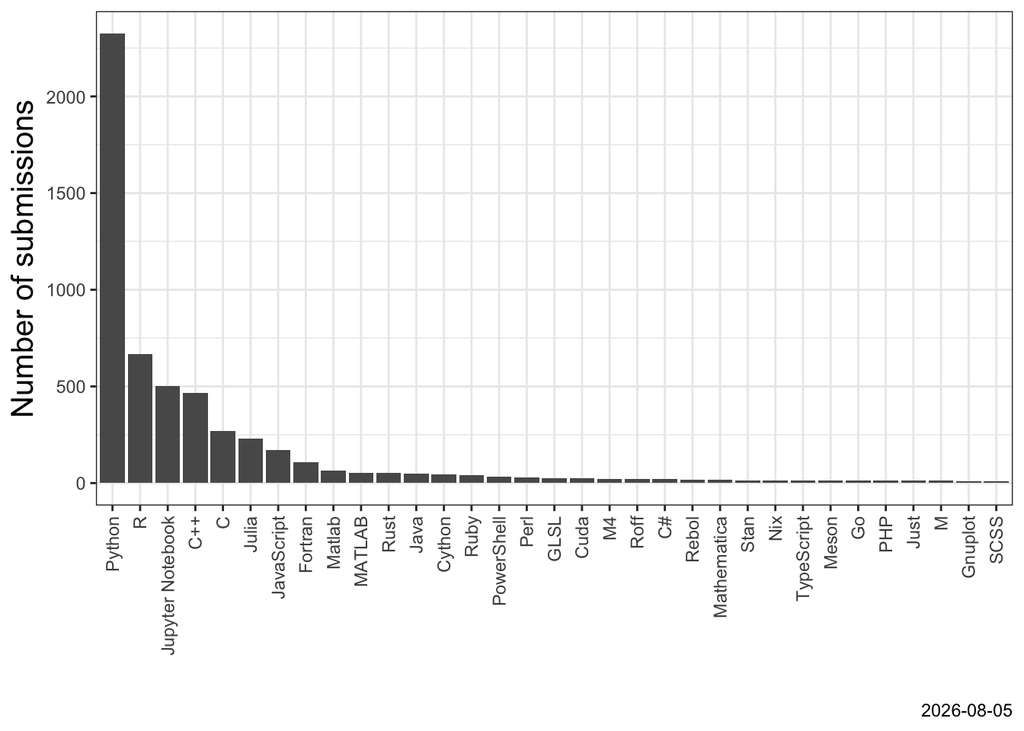

```r
ggplot(langs %>% dplyr::arrange(desc(nbr_submissions_JOSS_API)) %>%
           dplyr::filter(nbr_submissions_JOSS_API > 10) %>%
           dplyr::mutate(language = factor(language, levels = language)),
       aes(x = language, y = nbr_submissions_JOSS_API)) +
    geom_bar(stat = "identity") +
    theme_bw() +
    theme(axis.text.x = element_text(angle = 90, hjust = 1, vjust = 0.5)) +
    labs(x = "", y = "Number of submissions", caption = dcap) +
    theme(axis.title = element_text(size = 15))
```

```r
DT::datatable(
    langs %>% dplyr::arrange(desc(nbr_bytes_GitHub)),
    escape = FALSE,
    filter = list(position = 'top', clear = FALSE),
    options = list(scrollX = TRUE)
)
```

|  | language | nbr_submissions_JOSS_API | nbr_bytes_GitHub | nbr_repos_GitHub |
| --- | --- | --- | --- | --- |
| 1 | Jupyter Notebook | 503 | 2088708384 | 542 |
| 2 | Python | 2325 | 1559242649 | 2344 |
| 3 | C++ | 465 | 856071716 | 525 |
| 4 | HTML |  | 484772340 | 413 |
| 5 | C | 271 | 360915217 | 362 |
| 6 | Fortran | 108 | 300796506 | 131 |
| 7 | R | 667 | 197076817 | 681 |
| 8 | JavaScript | 170 | 161186884 | 247 |
| 9 | Julia | 230 | 106208448 | 247 |
| 10 | MATLAB | 54 | 94184374 | 144 |

[output cut: 243 more lines]

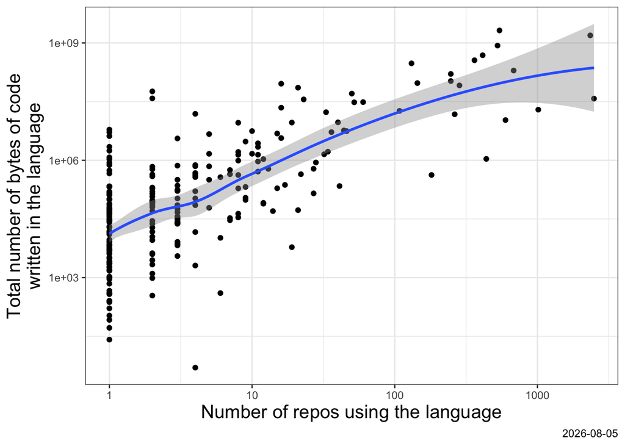

```r
ggplot(langs, aes(x = nbr_repos_GitHub, y = nbr_bytes_GitHub)) +
    geom_point() + scale_x_log10() + scale_y_log10() + geom_smooth() +
    theme_bw() +
    labs(x = "Number of repos using the language",
         y = "Total number of bytes of code\nwritten in the language",
         caption = dcap) +
    theme(axis.title = element_text(size = 15))
```

# Association between number of citations and number of stars of the GitHub repo

```r
ggplotly(
    ggplot(papers, aes(x = citation_count, y = repo_nbr_stars,
                       label = title)) +
        geom_point(alpha = 0.5) + scale_x_sqrt() + scale_y_sqrt() +
        theme_bw() +
        labs(x = "OpenAlex citation count", y = "Number of stars, GitHub repo",
             caption = dcap) +
        theme(axis.title = element_text(size = 15)),
    tooltip = c("label", "x", "y")
)
```

[interactive chart not shown]

# Distribution of time between GitHub repo creation and JOSS submission

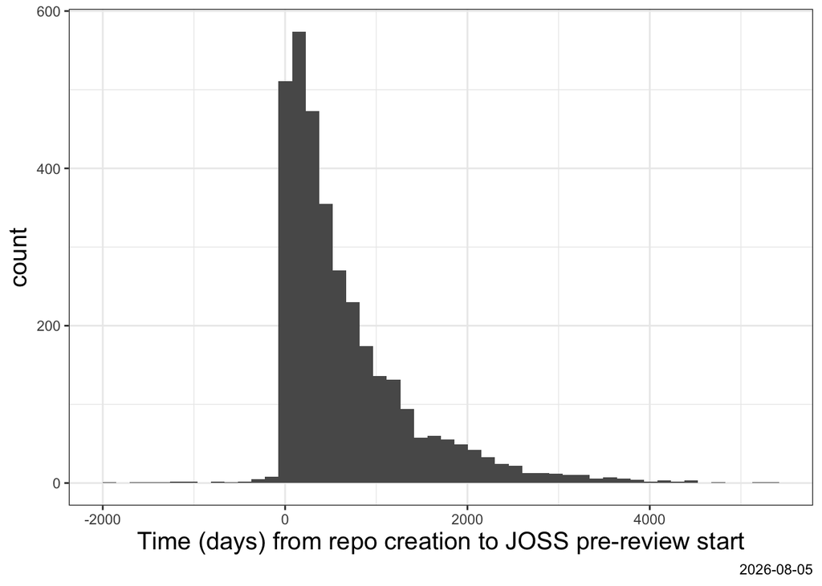

```r
ggplot(papers, aes(x = as.numeric(prerev_opened - repo_created))) +
    geom_histogram(bins = 50) +
    theme_bw() +
    labs(x = "Time (days) from repo creation to JOSS pre-review start",
         caption = dcap) +
    theme(axis.title = element_text(size = 15))
```

# Distribution of time between JOSS acceptance and last commit

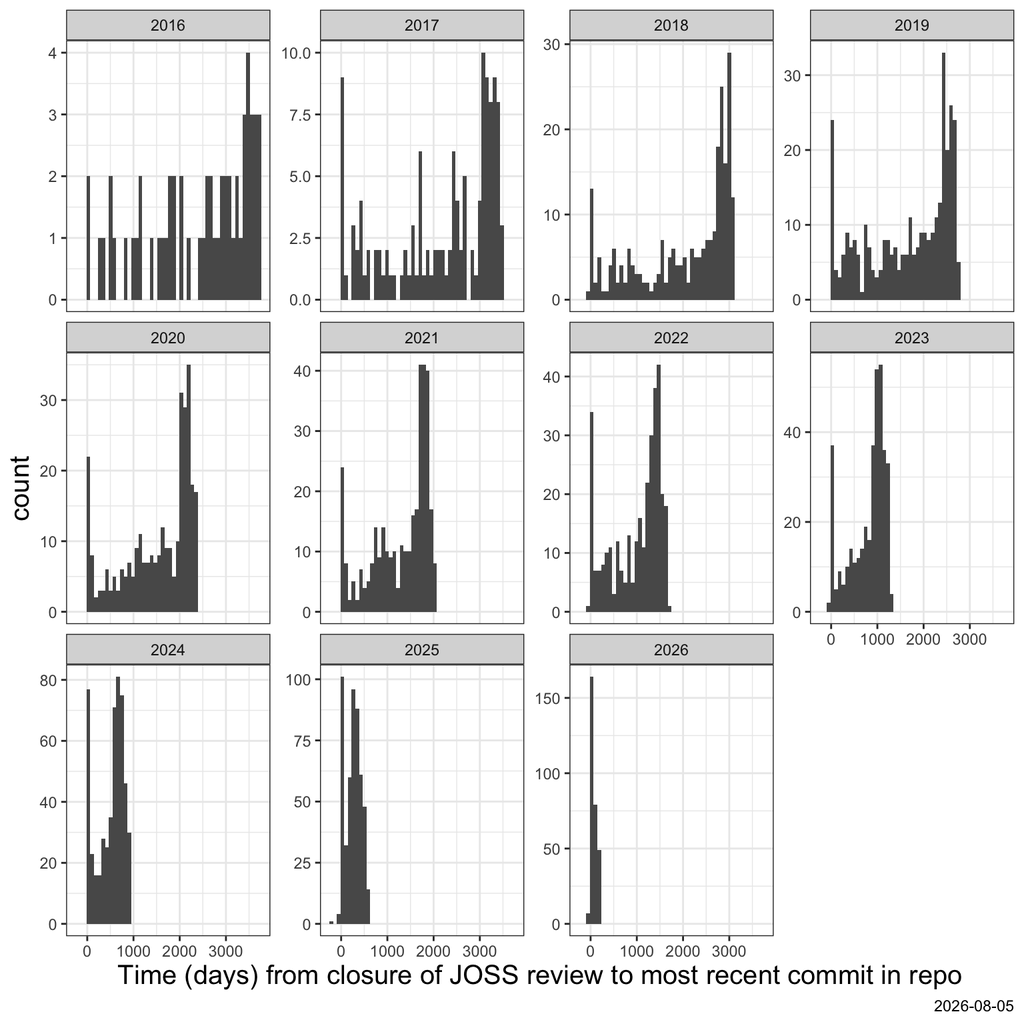

```r
ggplot(papers, aes(x = as.numeric(repo_pushed - review_closed))) +
    geom_histogram(bins = 50) +
    theme_bw() +
    labs(x = "Time (days) from closure of JOSS review to most recent commit in repo",
         caption = dcap) +
    theme(axis.title = element_text(size = 15)) +
    facet_wrap(~ year(published.date), scales = "free_y")
```

# Number of authors per paper

List the papers with the largest number of authors, and display the distribution of the number of authors per paper, for papers with at most 20 authors.

```r
## Papers with largest number of authors
papers %>% dplyr::arrange(desc(nbr_authors)) %>%
    dplyr::select(title, published.date, url, nbr_authors) %>%
    as.data.frame() %>% head(10)
```

```
##                                                                                                                          title
## 1                                                                                    SunPy: A Python package for Solar Physics
## 2                                                        ENZO: An Adaptive Mesh Refinement Code for Astrophysics (Version 2.6)
## 3                                 GEOS: A performance portable multi-physics simulation\nframework for subsurface applications
## 4  The Pencil Code, a modular MPI code for partial differential equations and particles: multipurpose and multiuser-maintained
## 5                                                             sbi reloaded: a toolkit for simulation-based inference workflows
## 6                                                     GRChombo: An adaptable numerical relativity code for fundamental physics
## 7                                       DataLad: distributed system for joint management of code, data, and their relationship
## 8                                                                                       PyBIDS: Python tools for BIDS datasets
## 9                                                                            Chaste: Cancer, Heart and Soft Tissue Environment
## 10                         sourmash v4: A multitool to quickly search, compare,\nand analyze genomic and metagenomic data sets
##    published.date                                 url nbr_authors
## 1      2020-02-14 https://doi.org/10.21105/joss.01832         124
## 2      2019-10-03 https://doi.org/10.21105/joss.01636          55
## 3      2024-10-10 https://doi.org/10.21105/joss.06973          53
## 4      2021-02-21 https://doi.org/10.21105/joss.02807          38
## 5      2025-04-08 https://doi.org/10.21105/joss.07754          33
## 6      2021-12-10 https://doi.org/10.21105/joss.03703          32
## 7      2021-07-01 https://doi.org/10.21105/joss.03262          31
## 8      2019-08-12 https://doi.org/10.21105/joss.01294          31
## 9      2020-03-13 https://doi.org/10.21105/joss.01848          29
## 10     2024-06-28 https://doi.org/10.21105/joss.06830          29
```

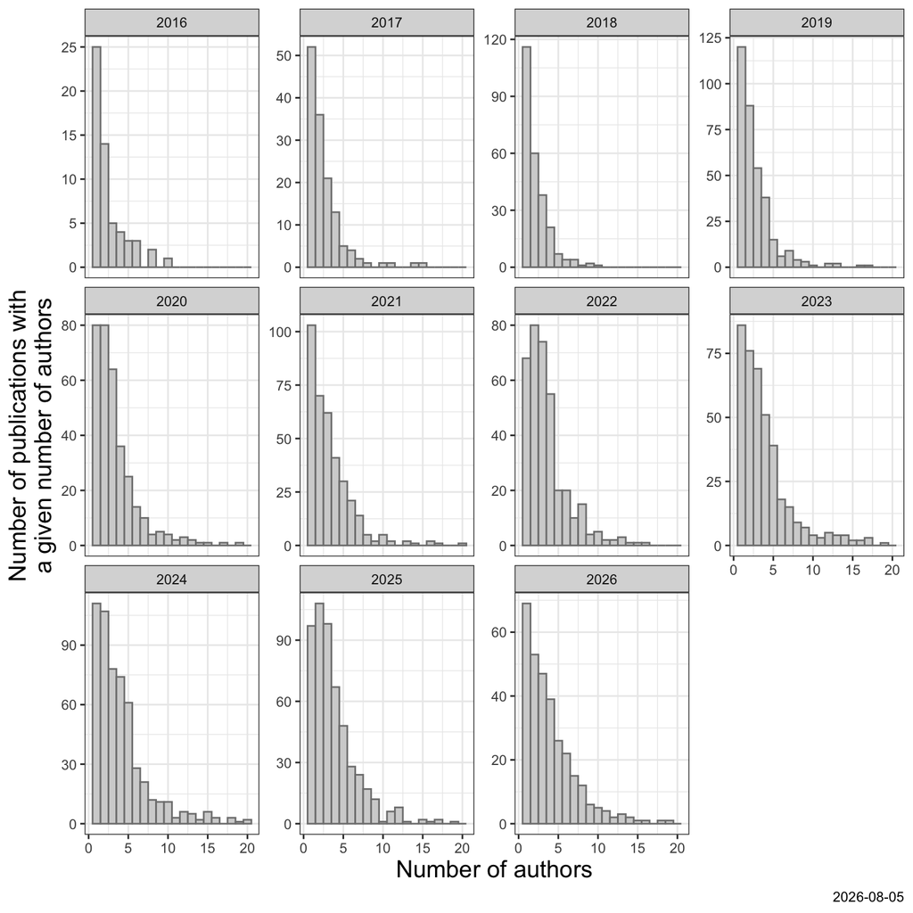

```r
nbins <- max(papers$nbr_authors[papers$nbr_authors <= 20])
ggplot(papers %>% dplyr::filter(nbr_authors <= 20),
       aes(x = nbr_authors)) +
    geom_histogram(bins = nbins, fill = "lightgrey", color = "grey50") +
    theme_bw() +
    facet_wrap(~ year(published.date), scales = "free_y") +
    theme(axis.title = element_text(size = 15)) +
    labs(x = "Number of authors",
         y = "Number of publications with\na given number of authors",
         caption = dcap)
```

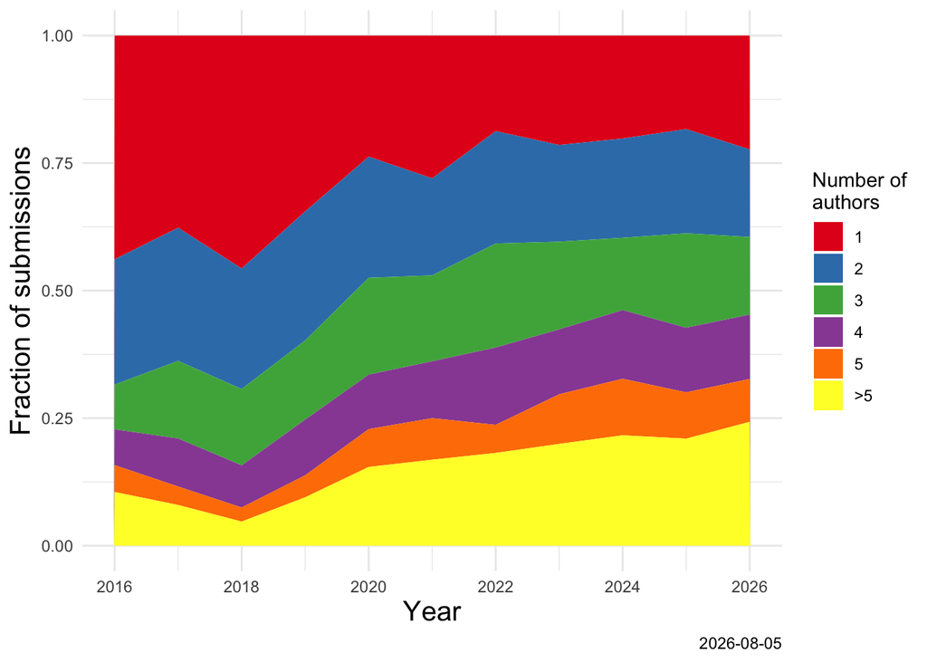

```r
ggplot(papers %>%
           dplyr::mutate(nbr_authors = replace(nbr_authors, nbr_authors > 5, ">5")) %>%
           dplyr::mutate(nbr_authors = factor(nbr_authors, levels = c("1", "2", "3",
                                                                      "4", "5", ">5"))) %>%
           dplyr::mutate(year = year(published.date)) %>%
           dplyr::mutate(year = factor(year)) %>%
           dplyr::group_by(year, nbr_authors, .drop = FALSE) %>%
           dplyr::summarize(n = n()) %>%
           dplyr::mutate(freq = n/sum(n)) %>%
           dplyr::mutate(year = as.integer(as.character(year))),
       aes(x = year, y = freq, fill = nbr_authors)) + geom_area() +
    theme_minimal() +
    scale_fill_brewer(palette = "Set1", name = "Number of\nauthors",
                      na.value = "grey") +
    theme(axis.title = element_text(size = 15)) +
    labs(x = "Year", y = "Fraction of submissions", caption = dcap)
```

# Number of authors vs number of contributors to the GitHub repo

Note that points are slightly jittered to reduce the overlap.

```r
plotly::ggplotly(
    ggplot(papers, aes(x = nbr_authors, y = repo_nbr_contribs_2ormore, label = title)) +
        geom_abline(slope = 1, intercept = 0) +
        geom_jitter(width = 0.05, height = 0.05, alpha = 0.5) +
        # geom_point(alpha = 0.5) +
        theme_bw() +
        scale_x_sqrt() + scale_y_sqrt() +
        labs(x = "Number of authors",
             y = "Number of contributors\nwith at least 2 commits",
             caption = dcap) +
        theme(axis.title = element_text(size = 15)),
    tooltip = c("label", "x", "y")
)
```

[interactive chart not shown]

# Number of reviewers per paper

Submissions associated with rOpenSci and pyOpenSci are not considered here, since they are not explicitly reviewed at JOSS.

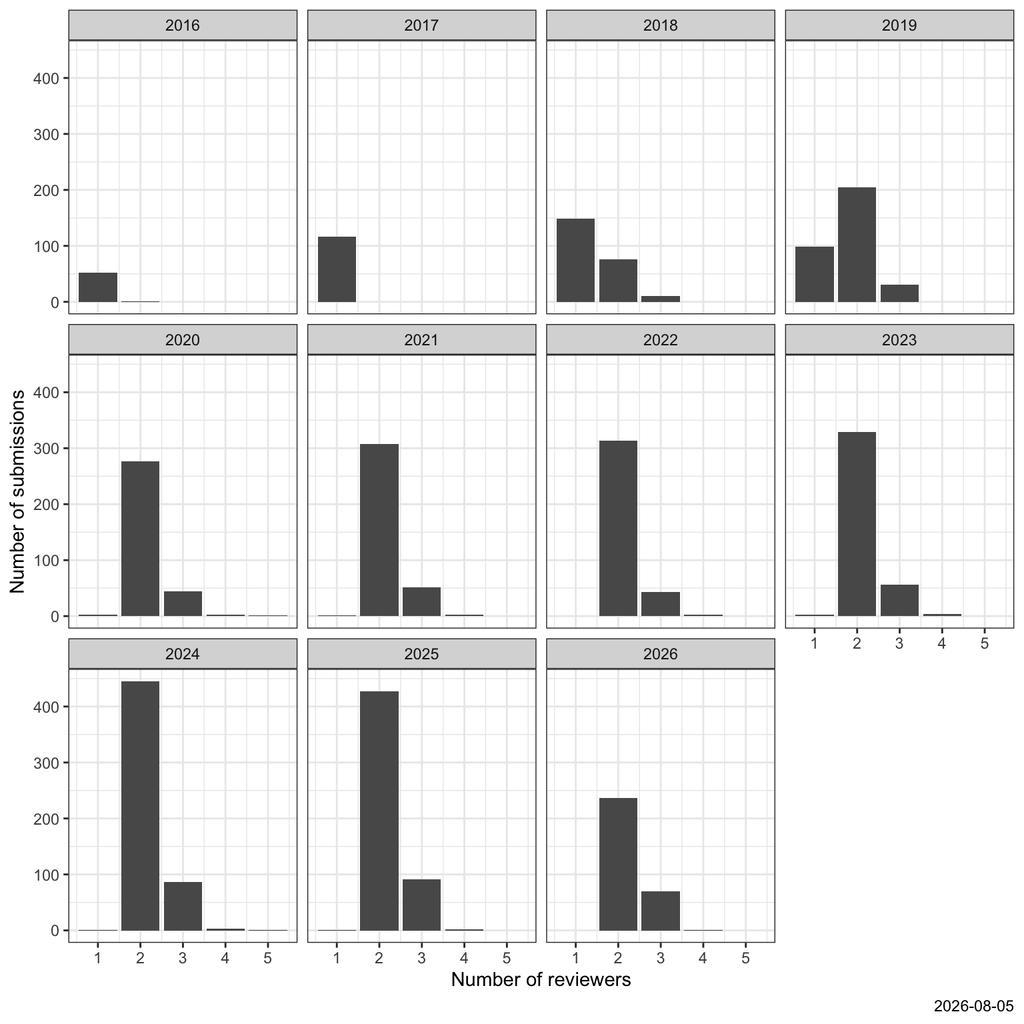

```r
ggplot(papers %>%
           dplyr::filter(!grepl("rOpenSci|pyOpenSci", prerev_labels)) %>%
           dplyr::mutate(year = year(published.date)),
       aes(x = nbr_reviewers)) + geom_bar() +
    facet_wrap(~ year) + theme_bw() +
    labs(x = "Number of reviewers", y = "Number of submissions", caption = dcap)
```

# Most active reviewers

Submissions associated with rOpenSci and pyOpenSci are not considered here, since they are not explicitly reviewed at JOSS.

## All time

```r
reviewers <- papers %>%
    dplyr::filter(!grepl("rOpenSci|pyOpenSci", prerev_labels)) %>%
    dplyr::mutate(year = year(published.date)) %>%
    dplyr::select(reviewers, year) %>%
    tidyr::separate_rows(reviewers, sep = ",")

## Most active reviewers
DT::datatable(
    reviewers %>% dplyr::group_by(reviewers) %>%
        dplyr::summarize(nbr_reviews = length(year),
                         timespan = paste(unique(c(min(year), max(year))),
                                          collapse = " - ")) %>%
        dplyr::arrange(desc(nbr_reviews)),
    escape = FALSE, rownames = FALSE,
    filter = list(position = 'top', clear = FALSE),
    options = list(scrollX = TRUE)
)
```

| reviewers | nbr_reviews | timespan |
| --- | --- | --- |
| @abhishektiwari | 30 | 2023 - 2026 |
| @amoeba | 16 | 2016 - 2025 |
| @matt-graham | 15 | 2021 - 2026 |
| @nicoguaro | 15 | 2016 - 2025 |
| @HaoZeke | 14 | 2018 - 2023 |
| @mattpitkin | 14 | 2018 - 2025 |
| @Chilipp | 13 | 2018 - 2026 |
| @Kevin-Mattheus-Moerman | 13 | 2016 - 2022 |
| @luizirber | 13 | 2016 - 2020 |
| @nhejazi | 13 | 2018 - 2025 |

[output cut: 3936 more lines]

## Past 5 years

```r
reviewers <- papers %>%
    dplyr::filter(!grepl("rOpenSci|pyOpenSci", prerev_labels)) %>%
    dplyr::mutate(year = year(published.date)) %>%
    dplyr::filter(as.Date(published.date) >= (lubridate::today() - 5 * 365.25)) %>%
    dplyr::select(reviewers, year) %>%
    tidyr::separate_rows(reviewers, sep = ",")

## Most active reviewers
DT::datatable(
    reviewers %>% dplyr::group_by(reviewers) %>%
        dplyr::summarize(nbr_reviews = length(year),
                         timespan = paste(unique(c(min(year), max(year))),
                                          collapse = " - ")) %>%
        dplyr::arrange(desc(nbr_reviews)),
    escape = FALSE, rownames = FALSE,
    filter = list(position = 'top', clear = FALSE),
    options = list(scrollX = TRUE)
)
```

| reviewers | nbr_reviews | timespan |
| --- | --- | --- |
| @abhishektiwari | 30 | 2023 - 2026 |
| @matt-graham | 15 | 2021 - 2026 |
| @Abinashbunty | 11 | 2023 - 2026 |
| @kanishkan91 | 11 | 2022 - 2026 |
| @idoby | 10 | 2022 - 2026 |
| @Athene-ai | 9 | 2022 - 2024 |
| @HectorMozo3110 | 9 | 2025 - 2026 |
| @lucaferranti | 9 | 2021 - 2025 |
| @nmstreethran | 9 | 2021 - 2025 |
| @vijaysm | 9 | 2021 - 2026 |

[output cut: 3052 more lines]

## Past year

```r
reviewers <- papers %>%
    dplyr::filter(!grepl("rOpenSci|pyOpenSci", prerev_labels)) %>%
    dplyr::mutate(year = year(published.date)) %>%
    dplyr::filter(as.Date(published.date) >= (lubridate::today() - 365.25)) %>%
    dplyr::select(reviewers, year) %>%
    tidyr::separate_rows(reviewers, sep = ",")

## Most active reviewers
DT::datatable(
    reviewers %>% dplyr::group_by(reviewers) %>%
        dplyr::summarize(nbr_reviews = length(year),
                         timespan = paste(unique(c(min(year), max(year))),
                                          collapse = " - ")) %>%
        dplyr::arrange(desc(nbr_reviews)),
    escape = FALSE, rownames = FALSE,
    filter = list(position = 'top', clear = FALSE),
    options = list(scrollX = TRUE)
)
```

| reviewers | nbr_reviews | timespan |
| --- | --- | --- |
| @HectorMozo3110 | 9 | 2025 - 2026 |
| @amcandio | 8 | 2025 - 2026 |
| @abhishektiwari | 7 | 2025 - 2026 |
| @HaoyuanHe0606 | 5 | 2026 |
| @Puneetha-Ramachandra | 5 | 2025 - 2026 |
| @tushardave26 | 5 | 2025 |
| @gmarupilla | 4 | 2026 |
| @majensen | 4 | 2025 - 2026 |
| @r0hin | 4 | 2026 |
| @KristinaGagalova | 3 | 2025 - 2026 |

[output cut: 952 more lines]

# Number of papers per editor and year

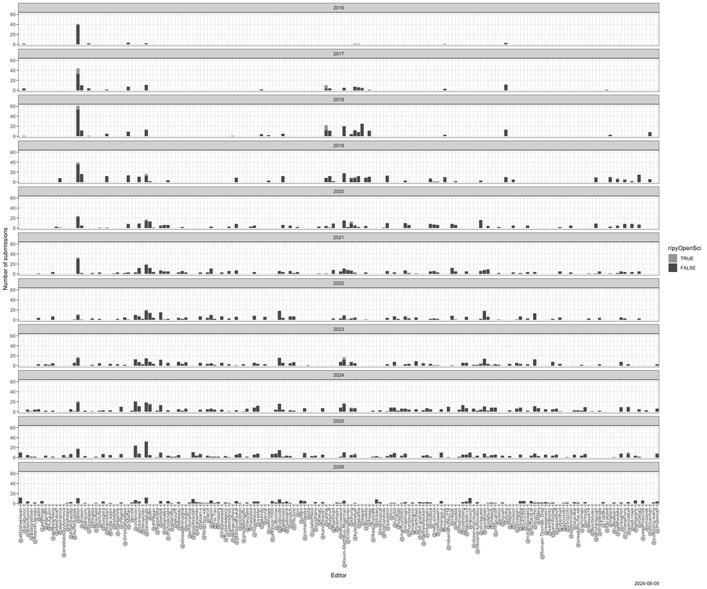

```r
ggplot(papers %>%
           dplyr::mutate(year = year(published.date),
                         `r/pyOpenSci` = factor(
                             grepl("rOpenSci|pyOpenSci", prerev_labels),
                             levels = c("TRUE", "FALSE"))),
       aes(x = editor)) + geom_bar(aes(fill = `r/pyOpenSci`)) +
    theme_bw() + facet_wrap(~ year, ncol = 1) +
    scale_fill_manual(values = c(`TRUE` = "grey65", `FALSE` = "grey35")) +
    theme(axis.text.x = element_text(angle = 90, hjust = 1, vjust = 0.5)) +
    labs(x = "Editor", y = "Number of submissions", caption = dcap)
```

# Distribution of software repo licenses

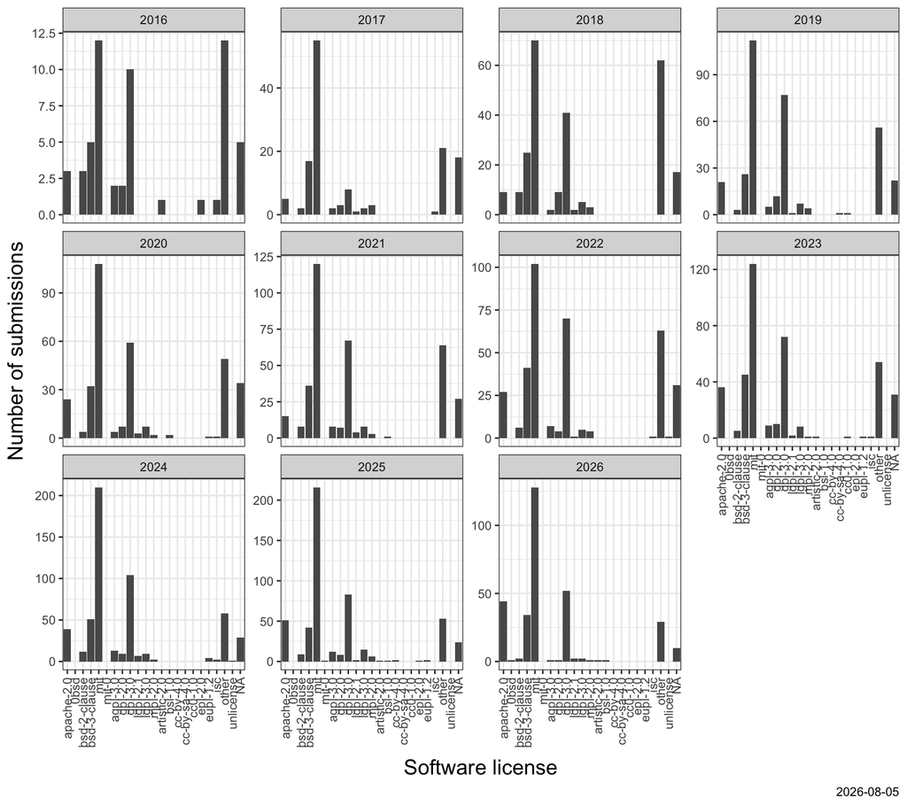

```r
all_licenses <- sort(unique(papers$repo_license))
license_levels = c(grep("apache", all_licenses, value = TRUE),
                   grep("bsd", all_licenses, value = TRUE),
                   grep("mit", all_licenses, value = TRUE),
                   grep("gpl", all_licenses, value = TRUE),
                   grep("mpl", all_licenses, value = TRUE))
license_levels <- c(license_levels, setdiff(all_licenses, license_levels))
ggplot(papers %>%
           dplyr::mutate(repo_license = factor(repo_license,
                                               levels = license_levels)),
       aes(x = repo_license)) +
    geom_bar() +
    theme_bw() +
    labs(x = "Software license", y = "Number of submissions", caption = dcap) +
    theme(axis.title = element_text(size = 15),
          axis.text.x = element_text(angle = 90, hjust = 1, vjust = 0.5)) +
    facet_wrap(~ year(published.date), scales = "free_y")
```

```r
## For plots below, replace licenses present in less
## than 2.5% of the submissions by 'other'
tbl <- table(papers$repo_license)
to_replace <- names(tbl[tbl <= 0.025 * nrow(papers)])
```

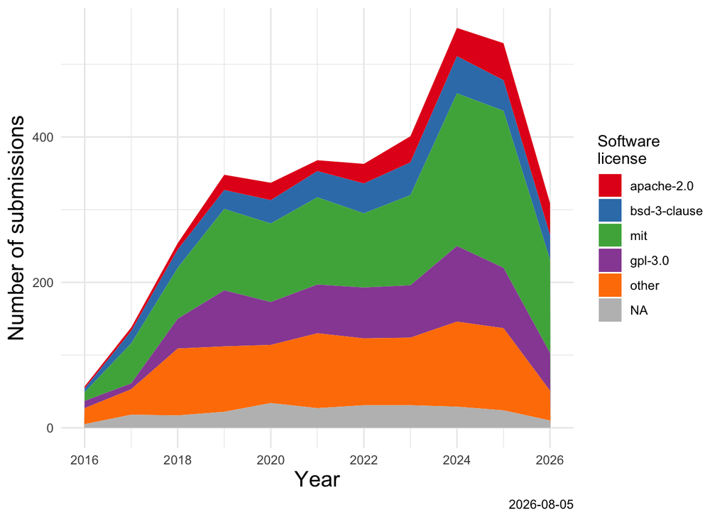

```r
ggplot(papers %>%
           dplyr::mutate(year = year(published.date)) %>%
           dplyr::mutate(repo_license = replace(repo_license,
                                                repo_license %in% to_replace,
                                                "other")) %>%
           dplyr::mutate(year = factor(year),
                         repo_license = factor(
                             repo_license,
                             levels = license_levels[license_levels %in% repo_license]
                         )) %>%
           dplyr::group_by(year, repo_license, .drop = FALSE) %>%
           dplyr::count() %>%
           dplyr::mutate(year = as.integer(as.character(year))),
       aes(x = year, y = n, fill = repo_license)) + geom_area() +
    theme_minimal() +
    scale_fill_brewer(palette = "Set1", name = "Software\nlicense",
                      na.value = "grey") +
    theme(axis.title = element_text(size = 15)) +
    labs(x = "Year", y = "Number of submissions", caption = dcap)
```

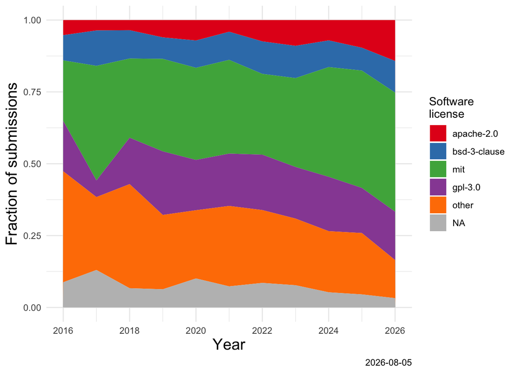

```r
ggplot(papers %>%
           dplyr::mutate(year = year(published.date)) %>%
           dplyr::mutate(repo_license = replace(repo_license,
                                                repo_license %in% to_replace,
                                                "other")) %>%
           dplyr::mutate(year = factor(year),
                         repo_license = factor(
                             repo_license,
                             levels = license_levels[license_levels %in% repo_license]
                         )) %>%
           dplyr::group_by(year, repo_license, .drop = FALSE) %>%
           dplyr::summarize(n = n()) %>%
           dplyr::mutate(freq = n/sum(n)) %>%
           dplyr::mutate(year = as.integer(as.character(year))),
       aes(x = year, y = freq, fill = repo_license)) + geom_area() +
    theme_minimal() +
    scale_fill_brewer(palette = "Set1", name = "Software\nlicense",
                      na.value = "grey") +
    theme(axis.title = element_text(size = 15)) +
    labs(x = "Year", y = "Fraction of submissions", caption = dcap)
```

# Most common GitHub repo topics

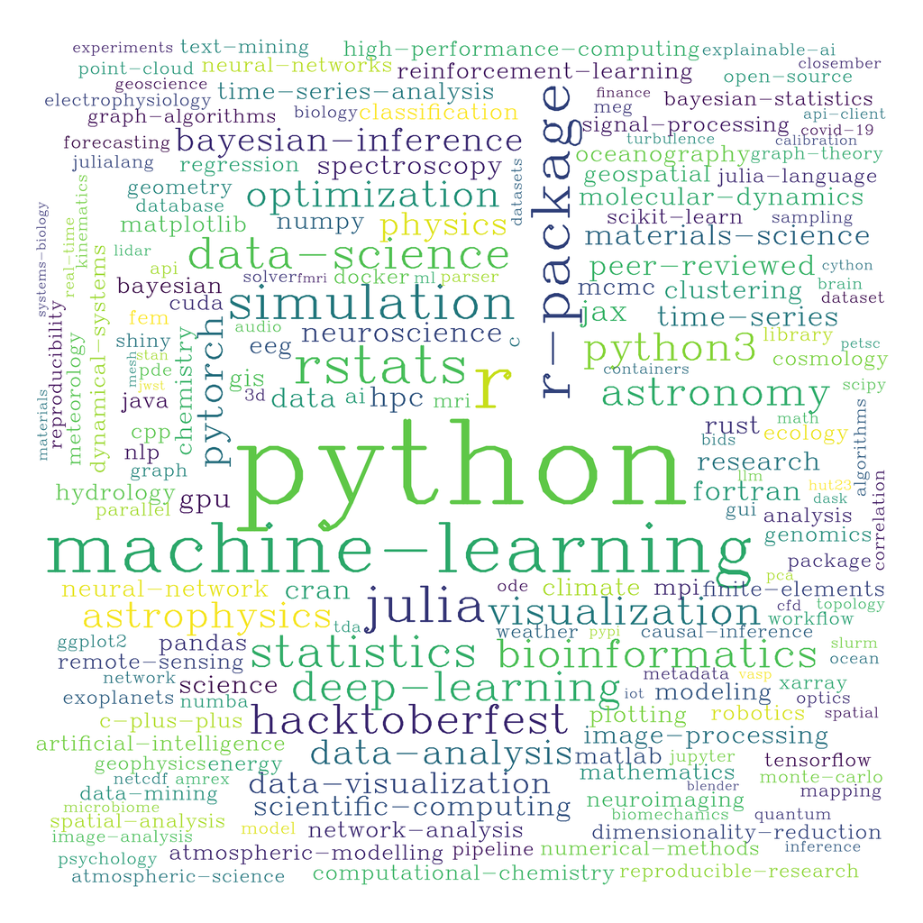

```r
a <- unlist(strsplit(papers$repo_topics, ","))
a <- a[!is.na(a)]
topicfreq <- table(a)

colors <- viridis::viridis(100)
set.seed(1234)
wordcloud::wordcloud(
    names(topicfreq), sqrt(topicfreq), min.freq = 1, max.words = 300,
    random.order = FALSE, rot.per = 0.05, use.r.layout = FALSE,
    colors = colors, scale = c(10, 0.1), random.color = TRUE,
    ordered.colors = FALSE, vfont = c("serif", "plain")
)
```

```r
DT::datatable(as.data.frame(topicfreq) %>%
                  dplyr::rename(topic = a, nbr_repos = Freq) %>%
                  dplyr::arrange(desc(nbr_repos)),
              escape = FALSE, rownames = FALSE,
              filter = list(position = 'top', clear = FALSE),
              options = list(scrollX = TRUE))
```

| topic | nbr_repos |
| --- | --- |
| python | 540 |
| r | 233 |
| machine-learning | 184 |
| r-package | 108 |
| rstats | 106 |
| julia | 95 |
| simulation | 89 |
| statistics | 74 |
| data-science | 71 |
| deep-learning | 63 |

[output cut: 6541 more lines]

# Citation analysis

Here, we take a more detailed look at the papers that cite JOSS papers, using data from the Open Citations Corpus.

## Get citing papers for each submission

```r
## Split into several queries
## Randomize the splitting since a whole query may fail if one ID is not recognized
papidx <- seq_len(nrow(papers))
idxL <- split(sample(papidx, length(papidx), replace = FALSE), ceiling(papidx / 50))
citationsL <- lapply(idxL, function(idx) {
    tryCatch({
        citecorp::oc_coci_cites(doi = papers$alternative.id[idx]) %>%
            dplyr::distinct() %>%
            dplyr::mutate(citation_info_obtained = as.character(lubridate::today()))
    }, error = function(e) {
        NULL
    })
})
citationsL <- citationsL[vapply(citationsL, function(df) !is.null(df) && nrow(df) > 0, FALSE)]
if (length(citationsL) > 0) {
    citations <- do.call(dplyr::bind_rows, citationsL)
} else {
    citations <- NULL
}
dim(citations)
```

```
## [1] 120185      8
```

```r
if (!is.null(citations) && is.data.frame(citations) && "oci" %in% colnames(citations)) {
    citations <- citations %>%
        dplyr::filter(!(oci %in% citations_archive$oci) &
                          citing != "")

    tmpj <- rcrossref::cr_works(dois = unique(citations$citing))$data %>%
        dplyr::select(contains("doi"), contains("container.title"), contains("issn"),
                      contains("type"), contains("publisher"), contains("prefix"))
    citations <- citations %>% dplyr::left_join(tmpj, by = c("citing" = "doi"))

    ## bioRxiv preprints don't have a 'container.title' or 'issn', but we'll assume
    ## that they can be
    ## identified from the prefix 10.1101 - set the container.title
    ## for these records manually; we may or may not want to count these
    ## (would it count citations twice, both preprint and publication?)
    citations$container.title[citations$prefix == "10.1101"] <- "bioRxiv"

    ## JOSS is represented by 'The Journal of Open Source Software' as well as
    ## 'Journal of Open Source Software'
    citations$container.title[citations$container.title ==
                                  "Journal of Open Source Software"] <-
        "The Journal of Open Source Software"

    ## Remove real self citations (cited DOI = citing DOI)
    citations <- citations %>% dplyr::filter(cited != citing)

    ## Merge with the archive
    citations <- dplyr::bind_rows(citations, citations_archive)
} else {
    citations <- citations_archive
    if (is.null(citations[["citation_info_obtained"]])) {
        citations$citation_info_obtained <- NA_character_
    }
}

citations$citation_info_obtained[is.na(citations$citation_info_obtained)] <-
    "2021-08-11"

write.table(citations, file = "joss_submission_citations.tsv",
            row.names = FALSE, col.names = TRUE, sep = "\t", quote = FALSE)
```

## Summary statistics

```r
## Latest successful update of new citation data
max(as.Date(citations$citation_info_obtained))
```

```
## [1] "2026-08-05"
```

```r
## Number of JOSS papers with >0 citations included in this collection
length(unique(citations$cited))
```

```
## [1] 2615
```

```r
## Number of JOSS papers with >0 citations according to OpenAlex
length(which(papers$citation_count > 0))
```

```
## [1] 2789
```

```r
## Number of citations from Open Citations Corpus vs OpenAlex
df0 <- papers %>% dplyr::select(doi, citation_count) %>%
    dplyr::full_join(citations %>% dplyr::group_by(cited) %>%
                         dplyr::tally() %>%
                         dplyr::mutate(n = replace(n, is.na(n), 0)),
                     by = c("doi" = "cited"))
```

```r
## Total citation count OpenAlex
sum(df0$citation_count, na.rm = TRUE)
```

```
## [1] 130571
```

```r
## Total citation count Open Citations Corpus
sum(df0$n, na.rm = TRUE)
```

```
## [1] 143608
```

```r
## Ratio of total citation count Open Citations Corpus/OpenAlex
sum(df0$n, na.rm = TRUE)/sum(df0$citation_count, na.rm = TRUE)
```

```
## [1] 1.099846
```

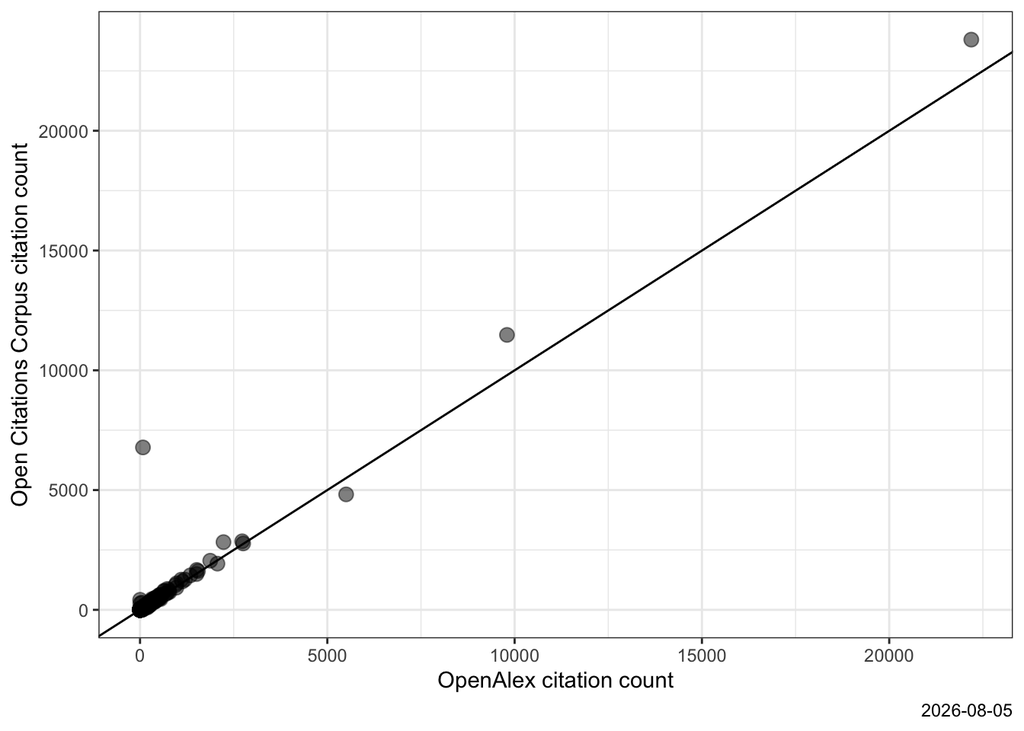

```r
ggplot(df0, aes(x = citation_count, y = n)) +
    geom_abline(slope = 1, intercept = 0) +
    geom_point(size = 3, alpha = 0.5) +
    labs(x = "OpenAlex citation count", y = "Open Citations Corpus citation count",
         caption = dcap) +
    theme_bw()
```

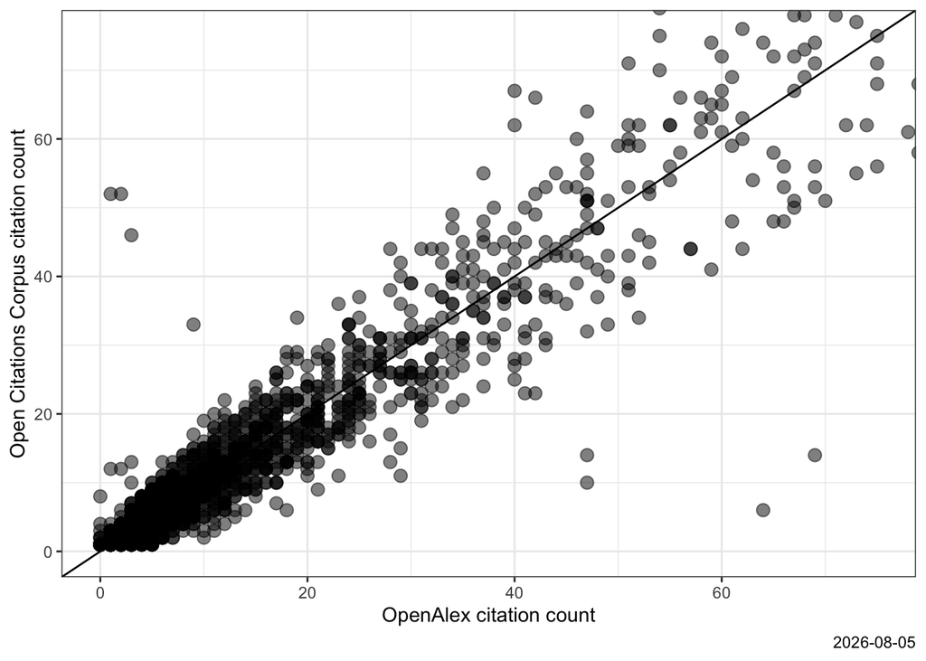

```r
## Zoom in
ggplot(df0, aes(x = citation_count, y = n)) +
    geom_abline(slope = 1, intercept = 0) +
    geom_point(size = 3, alpha = 0.5) +
    labs(x = "OpenAlex citation count", y = "Open Citations Corpus citation count",
         caption = dcap) +
    theme_bw() +
    coord_cartesian(xlim = c(0, 75), ylim = c(0, 75))
```

```r
## Number of journals citing JOSS papers
length(unique(citations$container.title))
```

```
## [1] 15164
```

```r
length(unique(citations$issn))
```

```
## [1] 10718
```

## Most citing journals

```r
topcit <- citations %>% dplyr::group_by(container.title) %>%
    dplyr::summarize(nbr_citations_of_joss_papers = length(cited),
                     nbr_cited_joss_papers = length(unique(cited)),
                     nbr_citing_papers = length(unique(citing)),
                     nbr_selfcitations_of_joss_papers = sum(author_sc == "yes"),
                     fraction_selfcitations = signif(nbr_selfcitations_of_joss_papers /
                                                         nbr_citations_of_joss_papers, digits = 3)) %>%
    dplyr::arrange(desc(nbr_cited_joss_papers))
DT::datatable(topcit,
              escape = FALSE, rownames = FALSE,
              filter = list(position = 'top', clear = FALSE),
              options = list(scrollX = TRUE))
```

| container.title | nbr_citations_of_joss_papers | nbr_cited_joss_papers | nbr_citing_papers | nbr_selfcitations_of_joss_papers | fraction_selfcitations |
| --- | --- | --- | --- | --- | --- |
|  | 9483 | 1036 | 8460 |  |  |
| The Journal of Open Source Software | 1671 | 642 | 863 | 356 | 0.213 |
| bioRxiv | 11343 | 499 | 7235 | 443 | 0.0391 |
| Scientific Reports | 2280 | 296 | 1649 | 12 | 0.00526 |
| Nature Communications | 1790 | 274 | 1292 | 50 | 0.0279 |
| CRAN: Contributed Packages | 318 | 240 | 293 | 180 | 0.566 |
| The Astrophysical Journal | 3431 | 204 | 2144 | 361 | 0.105 |
| Monthly Notices of the Royal Astronomical Society | 3124 | 193 | 1902 | 216 | 0.0691 |
| PLOS ONE | 1014 | 160 | 674 | 28 | 0.0276 |
| Astronomy &amp; Astrophysics | 1973 | 158 | 1503 | 81 | 0.0411 |

[output cut: 15154 more lines]

```r
plotly::ggplotly(
    ggplot(topcit, aes(x = nbr_citations_of_joss_papers, y = nbr_cited_joss_papers,
                       label = container.title)) +
        geom_abline(slope = 1, intercept = 0, linetype = "dashed", color = "grey") +
        geom_point(size = 3, alpha = 0.5) +
        theme_bw() +
        labs(caption = dcap, x = "Number of citations of JOSS papers",
             y = "Number of cited JOSS papers")
)
```

[interactive chart not shown]

```r
plotly::ggplotly(
    ggplot(topcit, aes(x = nbr_citations_of_joss_papers, y = nbr_cited_joss_papers,
                       label = container.title)) +
        geom_abline(slope = 1, intercept = 0, linetype = "dashed", color = "grey") +
        geom_point(size = 3, alpha = 0.5) +
        theme_bw() +
        coord_cartesian(xlim = c(0, 100), ylim = c(0, 50)) +
        labs(caption = dcap, x = "Number of citations of JOSS papers",
             y = "Number of cited JOSS papers")
)
```

[interactive chart not shown]

```r
write.table(topcit, file = "joss_submission_citations_byjournal.tsv",
            row.names = FALSE, col.names = TRUE, sep = "\t", quote = FALSE)
```

# Save object

The tibble object with all data collected above is serialized to a file that can be downloaded and reused.

```r
head(papers) %>% as.data.frame()
```

```
##        alternative.id                     container.title    created  deposited
## 1 10.21105/joss.07308     Journal of Open Source Software 2025-03-15 2025-03-15
## 2 10.21105/joss.01338     Journal of Open Source Software 2019-04-19 2019-11-17
## 3 10.21105/joss.01229     Journal of Open Source Software 2019-06-10 2024-07-19
## 4 10.21105/joss.01444     Journal of Open Source Software 2019-06-27 2022-09-22
## 5 10.21105/joss.00194 The Journal of Open Source Software 2017-03-07 2019-09-19
## 6 10.21105/joss.00650     Journal of Open Source Software 2018-04-15 2018-04-15
##   published.print                 doi    indexed      issn issue     issued
## 1      2025-03-15 10.21105/joss.07308 2025-03-16 2475-9066   107 2025-03-15
## 2      2019-04-19 10.21105/joss.01338 2025-02-21 2475-9066    36 2019-04-19
## 3      2019-06-10 10.21105/joss.01229 2025-02-21 2475-9066    38 2019-06-10
## 4      2019-06-27 10.21105/joss.01444 2025-02-21 2475-9066    38 2019-06-27
## 5      2017-03-07 10.21105/joss.00194 2025-02-21 2475-9066    11 2017-03-07
## 6      2018-04-15 10.21105/joss.00650 2025-02-21 2475-9066    24 2018-04-15
##   member page   prefix        publisher score   source reference.count
```

[output cut: 174 more lines]

```r
saveRDS(papers, file = "joss_submission_analytics.rds")
```

To read the current version of this file directly from GitHub, use the following code:

```r
papers <- readRDS(gzcon(url("https://github.com/openjournals/joss-analytics/blob/gh-pages/joss_submission_analytics.rds?raw=true")))
```

For non-R users, we also save a parquet file. For this, we convert any list column to a JSON string, and the difftime columns to numeric values.

```r
papers_parquet <- papers |>
     mutate(across(where(~ inherits(.x, "difftime")), as.numeric)) |>
     mutate(across(where(is.list), ~ map_chr(.x, ~ jsonlite::toJSON(.x))))
write_parquet(papers_parquet, "joss_submission_analytics.parquet")
```

This can be read into python as follows (assuming that `pandas` and `pyarrow` or `fastparquet` are available):

```python
import pandas as pd
papers = pd.read_parquet("https://github.com/openjournals/joss-analytics/blob/gh-pages/joss_submission_analytics.parquet?raw=true")
```